# Analysis of sound symbolic associations across experimental protocols

Léa de Carolis & Christophe Coupé

Thu Sep 03 20:37:14 2020

# 0. Preparatory steps & Introduction

## 0.1. Seeting document options

```
For best results, restart R session and update pander using devtools:: or remotes::install_github('rapporter/pander')
```

## 0.2. Loading libraries

```r
library(lme4) # For glm
library(MASS) # For polr
library(lsr) # For etaSquared
library(Epi) # For twoby2
library(car) # For Anova
library(emmeans) # For emmeans
library(questionr) # For Cramer's V
library(rsq) # For rsq.partial
library(scales) # To display percentages on the y-axis of a ggplot
library(tidyverse) # For tidy
library(kableExtra) # To format tables of results
library(PerformanceAnalytics) # For correlation charts
```

Setting the working directory

```r
my_path <- "D:/Dropbox/shared folders/Phonosymbolisme/Expe quatre protocoles/Final analysis"
setwd(my_path)
```

Setting the right contrasts for the regression models and the post-hoc tests

```r
options(contrasts=c("contr.sum","contr.poly")) # sum contrasts to get correct results with ANOVA (treatment contrasts lead to incorrect results)
emm_options(emmeans = list(type = "response"), contrast = list(infer = c(TRUE, TRUE))) # To get odd ratios with emmeans
```

This `Rmarkdown` script and the resulting `HTML` document contain the full analysis upon which the paper is based.

## 0.3. Hypotheses tested across protocols

| Hypothesis | Concept | Association 1 | Association 2 |
| --- | --- | --- | --- |
| 1 | Size | Voiced C – large | Voiceless C – small |
| 2 | Size | [i] – small | [a] – large |
| 3 | Biological class | Fricatives – fish | Plosives – bird |
| 4 | Biological class | [a] or [u] – fish | [i] – bird |
| 5 | Repulsiveness | Plosives – repulsive | Sonorants – attractive |
| 6 | Repulsiveness | [a] – repulsive | [i] – attractive |
| 7 | Dangerousness | Back V – dangerous | Front V – harmless |
| 8 | Dangerousness | Voiced C - dangerous | Voiceless C - harmless |
| 9 | Dangerousness | Plosives – dangerous | Sonorants – harmless |
| 10 | Dangerousness | Back C – dangerous | Front C - harmless |

## 0.4. A word of cautious regarding the statistical analyses

The odds ratio in fisher.test is conditional MLE, not unconditional MLE (= sample odds ratio) In glm, MLE are unconditional.

The partial R² computed for glm and polr models is Mckelvey Zavoina pseudo-R²

McKelvey, R. D., & Zavoina, W. (1975). A statistical model for the analysis of ordinal level dependent variables. The Journal of Mathematical Sociology, 4(1), 103–120

## 0.5. Generic functions for the analyses

### 0.5.2. Computations of Mckelvey Zavoina pseudo-R² for glm and polr models

For glm models:

```r
rsq.mz.glm <- function(model) {
  predicted.v <- predict(model)
  mean.predicted.v <- mean(predicted.v)
  ess <- sum((predicted.v - mean.predicted.v)^2) / length(predicted.v)
  pi.var <- (pi^2)/3
  return (ess / (ess + pi.var))
}
```

For ordered logistic models:

```r
rsq.mz.polr <- function(model) {
  ess <- var(model$lp)
  pi.var <- (pi^2)/3
  return (ess / (ess + pi.var))
}
```

### 0.5.2. Logistic regressions

Display and analysis - contingency table

```r
analyze_contingency_table <- function(hyp, variable) {
  contingency_table <- hyp %>%
                        group_by(.dots = c(variable, "label")) %>%
                        summarise(n = n()) %>%
                        spread(key = label, value = n) %>%
                        replace(., is.na(.), 0)
  mat <- as.matrix(contingency_table[,-1])
  rownames(mat) <- contingency_table %>% pull(variable)
  twb <- twoby2(mat, print=F)

  twb$table[,1:2] %>% kable(digits=4) %>% print()
  twb$measures %>% kable(digits=4) %>% print()
  cat(" \n\n")
  cat(paste0("Cramer's V (effect size): ", round(cramer.v(mat), 3)), "\n\n")
  cat(" \n\n")

  return(cramer.v(mat))
}
```

Analysis - binomial regression model

```r
analyze_binomial <- function(hyp, predictors) {

  # Assessing whether there is a single predictor
  if (length(predictors) == 1) {
    f.text <- paste("label", predictors[1], sep = " ~ ")
    cat(paste0("We run the binomial glm model '", f.text, "'\n\n"))

    model.simple <- glm(as.formula(f.text), data=hyp, family=binomial())
    anova.model.simple <- Anova(model.simple, type="III") # ANOVA

    R2 <- rsq.mz.glm(model.simple)
    cat(paste0("R2 = Effect size: ", round(R2, 4), "\n\n"))

    return(list(test.interaction = F, p.value.interaction = NA,
                p.value.target = anova.model.simple$'Pr(>Chisq)'[1], p.value.context = NA,
                effect.size.target = R2, effect.size.context = NA))
  }

  # There must be two predictors
  f.text <- paste("label", paste(predictors, collapse = " * "), sep = " ~ ")
  cat(paste0("We run the binomial glm model '", f.text, "'\n\n"))

  model.interaction <- glm(as.formula(f.text), data=hyp, family=binomial())
  anova.model.interaction <- Anova(model.interaction, type="III") # ANOVA
  anova.model.interaction %>% kable(digits=4) %>% print()

  p.value.interaction <- rev(anova.model.interaction$'Pr(>Chisq)')[1]
  test.interaction <- p.value.interaction < 0.05

  if(test.interaction) {
    cat(" \n\n")
    cat(paste0("There is an interaction since the p-value for it is equal to ", round(p.value.interaction, digits=4), "\n\n"))

    f.text.emm <- paste("pairwise", paste(predictors, collapse = " * "), sep = " ~ ")
    emm <- model.interaction %>% emmeans(as.formula(f.text.emm), adjust="none")
    emm$contrasts %>% kable(digits=3) %>% print()
  }
  else {
     cat(" \n\n")
     cat(paste0("There is no interaction since the p-value for the interaction is equal to ", round(p.value.interaction, digits=4), "\n\n"))
  }

  cat("We compute the model without interaction\n\n")

  f.text <- paste0(". ~ . - ", paste(predictors, collapse = ":"))
  model.no.interaction <- update(model.interaction, as.formula(f.text))
  anova.model.no.interaction <- Anova(model.no.interaction, type="III") # ANOVA
  R2.no.interaction <- rsq.mz.glm(model.no.interaction)

  cat("We compute the R² of the model without interaction and of two models without one predictor\n\n")

  f.text <- paste0(". ~ . - ", predictors[1])
  model.no.first.predictor <- update(model.no.interaction, as.formula(f.text))
  anova.model.no.interaction %>% kable(digits=4) %>% print()
  cat(" \n\n")

  R2.no.first.predictor <- rsq.mz.glm(model.no.first.predictor)

  f.text <- paste0(". ~ . - ", predictors[2])
  model.no.second.predictor <- update(model.no.interaction, as.formula(f.text))
  R2.no.second.predictor <- rsq.mz.glm(model.no.second.predictor)

  cat(paste0("R² model without interaction: ", round(R2.no.interaction, 4), "\n\n"))
  cat(paste0("R² model without first predictor: ", round(R2.no.first.predictor, 4), "\n\n"))
  cat(paste0("R² model without second predictor: ", round(R2.no.second.predictor, 4), "\n\n"))

  cat(paste0("Effect size first predictor: ", round(R2.no.interaction - R2.no.first.predictor, 4), "\n\n"))
  cat(paste0("Effect size second predictor: ", round(R2.no.interaction - R2.no.second.predictor, 4), "\n\n"))

  return(list(test.interaction = test.interaction, p.value.interaction = p.value.interaction,
              p.value.target = anova.model.no.interaction$'Pr(>Chisq)'[1], p.value.context = anova.model.no.interaction$'Pr(>Chisq)'[2],
              effect.size.target = R2.no.interaction - R2.no.first.predictor, effect.size.context = R2.no.interaction - R2.no.second.predictor))
}
```

### 0.5.3. Ordered logistic regressions

Display - 2x2 table of mean values

```r
analyze_means_table <- function(hyp, variable) {
  means_table <- hyp %>%
                  group_by(.dots = c(variable, "label")) %>%
                  summarise(m = mean(judgment)) %>%
                  spread(key = label, value = m) %>%
                  replace(., is.na(.), 0)

  means_table %>% kable(digits=4) %>% print()

  f.text <- paste0("judgment ~ label * ", variable)
  model.lm <- lm(as.formula(f.text), data=hyp)
  etasq <- etaSquared(model.lm, type=3)
  return(etasq[3,1])
}
```

Analysis - Ordered logistic regression model

```r
analyze_ordered_logistic <- function(hyp, predictors) {

  # Assessing whether there is a single predictor
  if (length(predictors) == 1) {
    f.text <- paste("response ~ label * ", predictors[1])
    cat(paste0("We run the ordered logistic regression model '", f.text, "'\n\n"))

    model.simple <- polr(as.formula(f.text), data=hyp)
    anova.model.simple <- Anova(model.simple, type="III") # ANOVA

    anova.model.simple %>% kable(digits=4) %>% print()

    R2.simple <- rsq.mz.polr(model.simple)

    f.text <- paste0(". ~ . - label:", predictors[1])
    model.reduced <- update(model.simple, as.formula(f.text))
    R2.reduced <- rsq.mz.polr(model.reduced)

    cat(paste0("R² initial model: ", round(R2.simple, 4), "\n\n"))
    cat(paste0("R² model without the interaction: ", round(R2.reduced, 4), "\n\n"))
    cat(paste0("Effect size of the predictor: ", round(R2.simple - R2.reduced, 4), "\n\n"))

    return(list(test.interaction = F, p.value.interaction = NA,
                p.value.target = anova.model.simple$'Pr(>Chisq)'[3], p.value.context = NA,
                effect.size.target = R2.simple - R2.reduced, effect.size.context = NA))
  }

  # There must be three predictors

  f.text <- paste0("response ~ label * ", paste(predictors, collapse = " * "))
  cat(paste0("We run the polr model '", f.text, "'\n\n"))
  model.interaction <- polr(as.formula(f.text), data=hyp)
  anova.model.interaction <- Anova(model.interaction, type="III") # ANOVA

  anova.model.interaction %>% kable(digits=4) %>% print()

  p.value.interaction <- anova.model.interaction$'Pr(>Chisq)'[7]
  test.interaction <- p.value.interaction < 0.05

  if(test.interaction) {
    cat(" \n\n")
    cat(paste0("There is an triple interaction since the p-value for it is equal to ", round(p.value.interaction, digits=4), "\n"))

    assign("f.text",  paste0("response ~ label * ", paste(predictors, collapse = " * ")), envir = .GlobalEnv) # A trick for emmeans to work with a polr model in a function
    f.text.emm <- paste0("pairwise ~ label * ", paste(predictors, collapse = " * "))

    emm <- model.interaction %>% emmeans(as.formula(f.text.emm), adjust="none")
    emm$contrasts %>% kable(digits=3) %>% print()
  }
  else {
    cat(" \n\n")
    cat(paste0("There is no triple interaction since the p-value for it is equal to ", round(p.value.interaction, digits=4), "\n\n"))
  }

  cat("We compute the model without interaction\n\n")

  f.text <- paste0(". ~ . - label:", paste(predictors, collapse = ":"))

  model.no.interaction <- update(model.interaction, as.formula(f.text))
  anova.model.no.interaction <- Anova(model.no.interaction, type="III") # ANOVA
  anova.model.no.interaction %>% kable(digits=4) %>% print()
  cat(" \n\n")

  R2.no.interaction <- rsq.mz.polr(model.no.interaction)

  cat("We compute the effect sizes of the full (without triple interaction) and two reduced models\n\n")

  f.text <- paste0(". ~ . - label:", predictors[1])
  model.no.first.predictor <- update(model.no.interaction, as.formula(f.text))
  R2.no.first.predictor <- rsq.mz.polr(model.no.first.predictor)

  f.text <- paste0(". ~ . - label:", predictors[2])
  model.no.second.predictor <- update(model.no.interaction, as.formula(f.text))
  R2.no.second.predictor <- rsq.mz.polr(model.no.second.predictor)

  cat(paste0("R² initial model: ", round(R2.no.interaction, 4), "\n\n"))
  cat(paste0("R² model without interaction including first predictor: ", round(R2.no.first.predictor, 4), "\n\n"))
  cat(paste0("R² model without interaction including second predictor: ", round(R2.no.second.predictor, 4), "\n\n"))

  cat(paste0("Effect size first predictor: ", round(R2.no.interaction - R2.no.first.predictor, 4), "\n\n"))
  cat(paste0("Effect size second predictor: ", round(R2.no.interaction - R2.no.second.predictor, 4), "\n\n"))

  return(list(test.interaction = test.interaction, p.value.interaction = p.value.interaction,
              p.value.target = anova.model.no.interaction$'Pr(>Chisq)'[4], p.value.context = anova.model.no.interaction$'Pr(>Chisq)'[5],
              effect.size.target = R2.no.interaction - R2.no.first.predictor, effect.size.context = R2.no.interaction - R2.no.second.predictor))
}
```

## 0.6 Storing the main results

```r
results <- tibble(protocol = rep("", 40), hypothesis = rep(0, 40), concept = rep("", 40),
                  label = rep("", 40), contrast = rep("", 40), context = rep("", 40),
                  preliminary.effect.size = rep(0.0, 40),
                  interaction = rep(F, 40), p.value.interaction = rep(0.0,40),
                  p.value.target = rep(0.0, 40), p.value.context = rep(0.0, 40),
                  effect.size.target = rep(0.0, 40), effect.size.context = rep(0.0, 40))
```

# 1. 2x2 data

## 1.1. Preparation of the data

Reading data:

```r
expe22 <- read.table("2x2.txt", sep = "\t", header = TRUE, dec = ".", stringsAsFactors = T)
expe22 <- as_tibble(expe22) # Turning the data frame into a tibble
```

Discarding training and trials without response (response time larger than 3000ms):

```r
expe22 <- expe22 %>%
            filter(trial_nb > 3) %>%
            filter(response_time < 3000) %>%
            droplevels()
```

Turning the variable subject_nr into a categorical variable:

```r
expe22 <- expe22 %>% mutate(subject_nr = as.factor(subject_nr))
```

Renaming variables to homogenize variable names across protocols for analysis:

```r
expe22 <- expe22 %>% rename(label = chosen_label) %>%
            rename(PW = chosen_PW)
```

## 1.2. Statistical analyses

### Hyp. 1: Voiced C - large & Voiceless C - small

Data Frame Summary

**hyp**  
**Dimensions**: 40 x 7  
**Duplicates**: 36

| **No** | **Variable** | **Stats / Values** | **Freqs (% of Valid)** | **Graph** | **Missing** |
| --- | --- | --- | --- | --- | --- |
| 1 | context [factor] | 1. a_a_ 2. i_i_ | 20 ( 50.0% ) 20 ( 50.0% ) |  | 0 (0%) |
| 2 | contrast [factor] | 1. p-b | 40 ( 100.0% ) |  | 0 (0%) |
| 3 | C [factor] | 1. b 2. p | 20 ( 50.0% ) 20 ( 50.0% ) |  | 0 (0%) |
| 4 | V [factor] | 1. a 2. i | 20 ( 50.0% ) 20 ( 50.0% ) |  | 0 (0%) |
| 5 | mode [factor] | 1. plosive | 40 ( 100.0% ) |  | 0 (0%) |
| 6 | place [factor] | 1. anterior | 40 ( 100.0% ) |  | 0 (0%) |
| 7 | voicing [factor] | 1. voiced 2. voiceless | 20 ( 50.0% ) 20 ( 50.0% ) |  | 0 (0%) |

|  | a_large_animal | a_small_animal |
| --- | --- | --- |
| b | 12 | 8 |
| p | 1 | 19 |

|  |  | 95% conf. | interval |
| --- | --- | --- | --- |
| Relative Risk: | 12.0000 | 1.7183 | 83.8030 |
| Sample Odds Ratio: | 28.5000 | 3.1551 | 257.4435 |
| Conditional MLE Odds Ratio: | 25.9804 | 2.9870 | 1270.0215 |
| Probability difference: | 0.5500 | 0.2668 | 0.7358 |

Cramer’s V (effect size): 0.587

We run the binomial glm model ‘label ~ C * V’

|  | LR Chisq | Df | Pr(>Chisq) |
| --- | --- | --- | --- |
| C | 17.8328 | 1 | 0.0000 |
| V | 4.0748 | 1 | 0.0435 |
| C:V | 0.1188 | 1 | 0.7304 |

There is no interaction since the p-value for the interaction is equal to 0.7304

We compute the model without interaction

We compute the R² of the model without interaction and of two models without one predictor

|  | LR Chisq | Df | Pr(>Chisq) |
| --- | --- | --- | --- |
| C | 20.0213 | 1 | 0.0000 |
| V | 7.3407 | 1 | 0.0067 |

R² model without interaction: 0.6577

R² model without first predictor: 0.0965

R² model without second predictor: 0.4603

Effect size first predictor: 0.5612

Effect size second predictor: 0.1974

### Hyp. 2: [i] - small & [a] - large

Data Frame Summary

**hyp**  
**Dimensions**: 42 x 7  
**Duplicates**: 38

| **No** | **Variable** | **Stats / Values** | **Freqs (% of Valid)** | **Graph** | **Missing** |
| --- | --- | --- | --- | --- | --- |
| 1 | context [factor] | 1. _b_b 2. _p_p | 21 ( 50.0% ) 21 ( 50.0% ) |  | 0 (0%) |
| 2 | contrast [factor] | 1. i-a | 42 ( 100.0% ) |  | 0 (0%) |
| 3 | C [factor] | 1. b 2. p | 21 ( 50.0% ) 21 ( 50.0% ) |  | 0 (0%) |
| 4 | V [factor] | 1. a 2. i | 15 ( 35.7% ) 27 ( 64.3% ) |  | 0 (0%) |
| 5 | mode [factor] | 1. plosive | 42 ( 100.0% ) |  | 0 (0%) |
| 6 | place [factor] | 1. anterior | 42 ( 100.0% ) |  | 0 (0%) |
| 7 | voicing [factor] | 1. voiced 2. voiceless | 21 ( 50.0% ) 21 ( 50.0% ) |  | 0 (0%) |

|  | a_large_animal | a_small_animal |
| --- | --- | --- |
| a | 9 | 6 |
| i | 0 | 27 |

|  |  | 95% conf. | interval |
| --- | --- | --- | --- |
| Relative Risk: | Inf |  | Inf |
| Sample Odds Ratio: | Inf |  | Inf |
| Conditional MLE Odds Ratio: | Inf | 6.2395 | Inf |
| Probability difference: | 0.6 | 0.3274 | 0.8018 |

Cramer’s V (effect size): 0.701

```
Warning in stats::chisq.test(tab, correct = FALSE): Chi-squared approximation may be incorrect
```

We run the binomial glm model ‘label ~ V * C’

|  | LR Chisq | Df | Pr(>Chisq) |
| --- | --- | --- | --- |
| V | 23.2434 | 1 | 0 |
| C | 0.0000 | 1 | 1 |
| V:C | 0.0000 | 1 | 1 |

There is no interaction since the p-value for the interaction is equal to 1

We compute the model without interaction

We compute the R² of the model without interaction and of two models without one predictor

|  | LR Chisq | Df | Pr(>Chisq) |
| --- | --- | --- | --- |
| V | 23.3573 | 1 | 0.0000 |
| C | 0.0446 | 1 | 0.8327 |

R² model without interaction: 0.9685

R² model without first predictor: 0.0061

R² model without second predictor: 0.9684

Effect size first predictor: 0.9624

Effect size second predictor: 0

### Hyp. 3: Fricatives - fish & Plosives - bird

Data Frame Summary

**hyp**  
**Dimensions**: 42 x 7  
**Duplicates**: 38

[output not shown]

|  | a_bird | a_fish |
| --- | --- | --- |
| s | 11 | 12 |
| t | 12 | 7 |

|  |  | 95% conf. | interval |
| --- | --- | --- | --- |
| Relative Risk: | 0.7572 | 0.4378 | 1.3097 |
| Sample Odds Ratio: | 0.5347 | 0.1547 | 1.8483 |
| Conditional MLE Odds Ratio: | 0.5428 | 0.1284 | 2.1702 |
| Probability difference: | -0.1533 | -0.4099 | 0.1396 |

Cramer’s V (effect size): 0.153

We run the binomial glm model ‘label ~ C * V’

|  | LR Chisq | Df | Pr(>Chisq) |
| --- | --- | --- | --- |
| C | 1.5592 | 1 | 0.2118 |
| V | 2.8731 | 1 | 0.0901 |
| C:V | 0.0873 | 1 | 0.7677 |

There is no interaction since the p-value for the interaction is equal to 0.7677

We compute the model without interaction

We compute the R² of the model without interaction and of two models without one predictor

|  | LR Chisq | Df | Pr(>Chisq) |
| --- | --- | --- | --- |
| C | 1.6324 | 1 | 0.2014 |
| V | 3.0661 | 1 | 0.0799 |

R² model without interaction: 0.1173

R² model without first predictor: 0.0681

R² model without second predictor: 0.0287

Effect size first predictor: 0.0492

Effect size second predictor: 0.0887

### Hyp. 4: [a] or [u] - fish & [i] - bird

Data Frame Summary

**hyp**  
**Dimensions**: 38 x 7  
**Duplicates**: 34

| **No** | **Variable** | **Stats / Values** | **Freqs (% of Valid)** | **Graph** | **Missing** |
| --- | --- | --- | --- | --- | --- |
| 1 | context [factor] | 1. _s_s 2. _t_t | 20 ( 52.6% ) 18 ( 47.4% ) |  | 0 (0%) |
| 2 | contrast [factor] | 1. i-a | 38 ( 100.0% ) |  | 0 (0%) |
| 3 | C [factor] | 1. s 2. t | 20 ( 52.6% ) 18 ( 47.4% ) |  | 0 (0%) |
| 4 | V [factor] | 1. a 2. i | 14 ( 36.8% ) 24 ( 63.2% ) |  | 0 (0%) |
| 5 | mode [factor] | 1. fricative 2. plosive | 20 ( 52.6% ) 18 ( 47.4% ) |  | 0 (0%) |
| 6 | place [factor] | 1. medium | 38 ( 100.0% ) |  | 0 (0%) |
| 7 | voicing [factor] | 1. voiceless | 38 ( 100.0% ) |  | 0 (0%) |

|  | a_bird | a_fish |
| --- | --- | --- |
| a | 4 | 10 |
| i | 17 | 7 |

|  |  | 95% conf. | interval |
| --- | --- | --- | --- |
| Relative Risk: | 0.4034 | 0.1695 | 0.9600 |
| Sample Odds Ratio: | 0.1647 | 0.0384 | 0.7062 |
| Conditional MLE Odds Ratio: | 0.1739 | 0.0290 | 0.8535 |
| Probability difference: | -0.4226 | -0.6433 | -0.0940 |

Cramer’s V (effect size): 0.41

We run the binomial glm model ‘label ~ V * C’

|  | LR Chisq | Df | Pr(>Chisq) |
| --- | --- | --- | --- |
| V | 6.5647 | 1 | 0.0104 |
| C | 0.0130 | 1 | 0.9092 |
| V:C | 0.0130 | 1 | 0.9092 |

There is no interaction since the p-value for the interaction is equal to 0.9092

We compute the model without interaction

We compute the R² of the model without interaction and of two models without one predictor

|  | LR Chisq | Df | Pr(>Chisq) |
| --- | --- | --- | --- |
| V | 6.5524 | 1 | 0.0105 |
| C | 0.0223 | 1 | 0.8812 |

R² model without interaction: 0.1878

R² model without first predictor: 0

R² model without second predictor: 0.187

Effect size first predictor: 0.1878

Effect size second predictor: 8e-04

### Hyp. 5: Plosives – repulsive & Sonorants – attractive

Data Frame Summary

**hyp**  
**Dimensions**: 38 x 7  
**Duplicates**: 34

| **No** | **Variable** | **Stats / Values** | **Freqs (% of Valid)** | **Graph** | **Missing** |
| --- | --- | --- | --- | --- | --- |
| 1 | context [factor] | 1. a_a_ 2. i_i_ | 19 ( 50.0% ) 19 ( 50.0% ) |  | 0 (0%) |
| 2 | contrast [factor] | 1. n-k | 38 ( 100.0% ) |  | 0 (0%) |
| 3 | C [factor] | 1. k 2. n | 23 ( 60.5% ) 15 ( 39.5% ) |  | 0 (0%) |
| 4 | V [factor] | 1. a 2. i | 19 ( 50.0% ) 19 ( 50.0% ) |  | 0 (0%) |
| 5 | mode [factor] | 1. plosive 2. sonorant | 23 ( 60.5% ) 15 ( 39.5% ) |  | 0 (0%) |
| 6 | place [factor] | 1. medium 2. posterior | 15 ( 39.5% ) 23 ( 60.5% ) |  | 0 (0%) |
| 7 | voicing [factor] | 1. voiced 2. voiceless | 15 ( 39.5% ) 23 ( 60.5% ) |  | 0 (0%) |

|  | a_repulsive_animal | an_attractive_animal |
| --- | --- | --- |
| k | 15 | 8 |
| n | 3 | 12 |

|  |  | 95% conf. | interval |
| --- | --- | --- | --- |
| Relative Risk: | 3.2609 | 1.1352 | 9.3671 |
| Sample Odds Ratio: | 7.5000 | 1.6261 | 34.5909 |
| Conditional MLE Odds Ratio: | 7.0693 | 1.3660 | 50.8041 |
| Probability difference: | 0.4522 | 0.1285 | 0.6578 |

Cramer’s V (effect size): 0.443

We run the binomial glm model ‘label ~ C * V’

|  | LR Chisq | Df | Pr(>Chisq) |
| --- | --- | --- | --- |
| C | 7.9394 | 1 | 0.0048 |
| V | 3.0362 | 1 | 0.0814 |
| C:V | 0.2023 | 1 | 0.6529 |

There is no interaction since the p-value for the interaction is equal to 0.6529

We compute the model without interaction

We compute the R² of the model without interaction and of two models without one predictor

|  | LR Chisq | Df | Pr(>Chisq) |
| --- | --- | --- | --- |
| C | 8.1290 | 1 | 0.0044 |
| V | 4.1542 | 1 | 0.0415 |

R² model without interaction: 0.3591

R² model without first predictor: 0.1157

R² model without second predictor: 0.2277

Effect size first predictor: 0.2434

Effect size second predictor: 0.1314

### Hyp. 6: [a] - repulsive & [i] - attractive

Data Frame Summary

**hyp**  
**Dimensions**: 41 x 7  
**Duplicates**: 37

| **No** | **Variable** | **Stats / Values** | **Freqs (% of Valid)** | **Graph** | **Missing** |
| --- | --- | --- | --- | --- | --- |
| 1 | context [factor] | 1. _k_k 2. _n_n | 21 ( 51.2% ) 20 ( 48.8% ) |  | 0 (0%) |
| 2 | contrast [factor] | 1. i-a | 41 ( 100.0% ) |  | 0 (0%) |
| 3 | C [factor] | 1. k 2. n | 21 ( 51.2% ) 20 ( 48.8% ) |  | 0 (0%) |
| 4 | V [factor] | 1. a 2. i | 22 ( 53.7% ) 19 ( 46.3% ) |  | 0 (0%) |
| 5 | mode [factor] | 1. plosive 2. sonorant | 21 ( 51.2% ) 20 ( 48.8% ) |  | 0 (0%) |
| 6 | place [factor] | 1. medium 2. posterior | 20 ( 48.8% ) 21 ( 51.2% ) |  | 0 (0%) |
| 7 | voicing [factor] | 1. voiced 2. voiceless | 20 ( 48.8% ) 21 ( 51.2% ) |  | 0 (0%) |

|  | a_repulsive_animal | an_attractive_animal |
| --- | --- | --- |
| a | 20 | 2 |
| i | 1 | 18 |

|  |  | 95% conf. | interval |
| --- | --- | --- | --- |
| Relative Risk: | 17.2727 | 2.5520 | 116.9082 |
| Sample Odds Ratio: | 180.0000 | 15.0214 | 2156.9218 |
| Conditional MLE Odds Ratio: | 133.2238 | 12.3282 | 7304.7241 |
| Probability difference: | 0.8565 | 0.5870 | 0.9351 |

Cramer’s V (effect size): 0.854

We run the binomial glm model ‘label ~ V * C’

|  | LR Chisq | Df | Pr(>Chisq) |
| --- | --- | --- | --- |
| V | 38.2327 | 1 | 0.0000 |
| C | 2.8805 | 1 | 0.0897 |
| V:C | 0.0000 | 1 | 1.0000 |

There is no interaction since the p-value for the interaction is equal to 1

We compute the model without interaction

We compute the R² of the model without interaction and of two models without one predictor

|  | LR Chisq | Df | Pr(>Chisq) |
| --- | --- | --- | --- |
| V | 38.5436 | 1 | 0.000 |
| C | 3.1928 | 1 | 0.074 |

R² model without interaction: 0.9788

R² model without first predictor: 0.0066

R² model without second predictor: 0.6709

Effect size first predictor: 0.9722

Effect size second predictor: 0.308

### Hyp. 7: Back V - dangerous & Front V - harmless

Data Frame Summary

**hyp**  
**Dimensions**: 41 x 7  
**Duplicates**: 37

| **No** | **Variable** | **Stats / Values** | **Freqs (% of Valid)** | **Graph** | **Missing** |
| --- | --- | --- | --- | --- | --- |
| 1 | context [factor] | 1. _g_g 2. _m_m | 21 ( 51.2% ) 20 ( 48.8% ) |  | 0 (0%) |
| 2 | contrast [factor] | 1. i-u | 41 ( 100.0% ) |  | 0 (0%) |
| 3 | C [factor] | 1. g 2. m | 21 ( 51.2% ) 20 ( 48.8% ) |  | 0 (0%) |
| 4 | V [factor] | 1. i 2. u | 20 ( 48.8% ) 21 ( 51.2% ) |  | 0 (0%) |
| 5 | mode [factor] | 1. plosive 2. sonorant | 21 ( 51.2% ) 20 ( 48.8% ) |  | 0 (0%) |
| 6 | place [factor] | 1. anterior 2. posterior | 20 ( 48.8% ) 21 ( 51.2% ) |  | 0 (0%) |
| 7 | voicing [factor] | 1. voiced | 41 ( 100.0% ) |  | 0 (0%) |

|  | a_dangerous_animal | a_harmless_animal |
| --- | --- | --- |
| i | 5 | 15 |
| u | 11 | 10 |

|  |  | 95% conf. | interval |
| --- | --- | --- | --- |
| Relative Risk: | 0.4773 | 0.2016 | 1.1298 |
| Sample Odds Ratio: | 0.3030 | 0.0805 | 1.1410 |
| Conditional MLE Odds Ratio: | 0.3124 | 0.0637 | 1.3483 |
| Probability difference: | -0.2738 | -0.5109 | 0.0226 |

Cramer’s V (effect size): 0.281

We run the binomial glm model ‘label ~ V * C’

|  | LR Chisq | Df | Pr(>Chisq) |
| --- | --- | --- | --- |
| V | 1.9064 | 1 | 0.1674 |
| C | 4.8643 | 1 | 0.0274 |
| V:C | 1.0857 | 1 | 0.2974 |

There is no interaction since the p-value for the interaction is equal to 0.2974

We compute the model without interaction

We compute the R² of the model without interaction and of two models without one predictor

|  | LR Chisq | Df | Pr(>Chisq) |
| --- | --- | --- | --- |
| V | 2.6934 | 1 | 0.1008 |
| C | 5.5531 | 1 | 0.0184 |

R² model without interaction: 0.2572

R² model without first predictor: 0.1755

R² model without second predictor: 0.0977

Effect size first predictor: 0.0817

Effect size second predictor: 0.1595

### Hyp. 8: Voiced C - dangerous & Voiceless C - harmless

Data Frame Summary

**hyp**  
**Dimensions**: 40 x 7  
**Duplicates**: 36

| **No** | **Variable** | **Stats / Values** | **Freqs (% of Valid)** | **Graph** | **Missing** |
| --- | --- | --- | --- | --- | --- |
| 1 | context [factor] | 1. u_u_ | 40 ( 100.0% ) |  | 0 (0%) |
| 2 | contrast [factor] | 1. k-g 2. p-b | 20 ( 50.0% ) 20 ( 50.0% ) |  | 0 (0%) |
| 3 | C [factor] | 1. b 2. g 3. k 4. p | 8 ( 20.0% ) 8 ( 20.0% ) 12 ( 30.0% ) 12 ( 30.0% ) |  | 0 (0%) |
| 4 | V [factor] | 1. u | 40 ( 100.0% ) |  | 0 (0%) |
| 5 | mode [factor] | 1. plosive | 40 ( 100.0% ) |  | 0 (0%) |
| 6 | place [factor] | 1. anterior 2. posterior | 20 ( 50.0% ) 20 ( 50.0% ) |  | 0 (0%) |
| 7 | voicing [factor] | 1. voiced 2. voiceless | 16 ( 40.0% ) 24 ( 60.0% ) |  | 0 (0%) |

|  | a_dangerous_animal | a_harmless_animal |
| --- | --- | --- |
| voiced | 13 | 3 |
| voiceless | 12 | 12 |

|  |  | 95% conf. | interval |
| --- | --- | --- | --- |
| Relative Risk: | 1.6250 | 1.0216 | 2.5849 |
| Sample Odds Ratio: | 4.3333 | 0.9779 | 19.2024 |
| Conditional MLE Odds Ratio: | 4.1764 | 0.8358 | 28.7690 |
| Probability difference: | 0.3125 | 0.0070 | 0.5345 |

Cramer’s V (effect size): 0.316

We run the binomial glm model ‘label ~ voicing * place’

|  | LR Chisq | Df | Pr(>Chisq) |
| --- | --- | --- | --- |
| voicing | 4.1664 | 1 | 0.0412 |
| place | 2.0609 | 1 | 0.1511 |
| voicing:place | 0.1111 | 1 | 0.7389 |

There is no interaction since the p-value for the interaction is equal to 0.7389

We compute the model without interaction

We compute the R² of the model without interaction and of two models without one predictor

|  | LR Chisq | Df | Pr(>Chisq) |
| --- | --- | --- | --- |
| voicing | 4.5298 | 1 | 0.0333 |
| place | 3.0240 | 1 | 0.0820 |

R² model without interaction: 0.2303

R² model without first predictor: 0.084

R² model without second predictor: 0.1356

Effect size first predictor: 0.1463

Effect size second predictor: 0.0947

### Hyp. 9: Plosives - dangerous & Sonorants - harmless

Data Frame Summary

**hyp**  
**Dimensions**: 60 x 7  
**Duplicates**: 56

| **No** | **Variable** | **Stats / Values** | **Freqs (% of Valid)** | **Graph** | **Missing** |
| --- | --- | --- | --- | --- | --- |
| 1 | context [factor] | 1. i_i_ 2. u_u_ | 40 ( 66.7% ) 20 ( 33.3% ) |  | 0 (0%) |
| 2 | contrast [factor] | 1. b-m 2. l-d | 20 ( 33.3% ) 40 ( 66.7% ) |  | 0 (0%) |
| 3 | C [factor] | 1. b 2. d 3. l 4. m | 10 ( 16.7% ) 17 ( 28.3% ) 23 ( 38.3% ) 10 ( 16.7% ) |  | 0 (0%) |
| 4 | V [factor] | 1. i 2. u | 40 ( 66.7% ) 20 ( 33.3% ) |  | 0 (0%) |
| 5 | mode [factor] | 1. plosive 2. sonorant | 27 ( 45.0% ) 33 ( 55.0% ) |  | 0 (0%) |
| 6 | place [factor] | 1. anterior 2. medium | 20 ( 33.3% ) 40 ( 66.7% ) |  | 0 (0%) |
| 7 | voicing [factor] | 1. voiced | 60 ( 100.0% ) |  | 0 (0%) |

|  | a_dangerous_animal | a_harmless_animal |
| --- | --- | --- |
| plosive | 17 | 10 |
| sonorant | 3 | 30 |

|  |  | 95% conf. | interval |
| --- | --- | --- | --- |
| Relative Risk: | 6.9259 | 2.2665 | 21.1641 |
| Sample Odds Ratio: | 17.0000 | 4.1059 | 70.3867 |
| Conditional MLE Odds Ratio: | 16.0206 | 3.6171 | 103.3452 |
| Probability difference: | 0.5387 | 0.3019 | 0.7048 |

Cramer’s V (effect size): 0.569

We run the binomial glm model ‘label ~ mode * place’

|  | LR Chisq | Df | Pr(>Chisq) |
| --- | --- | --- | --- |
| mode | 20.7579 | 1 | 0.0000 |
| place | 0.7541 | 1 | 0.3852 |
| mode:place | 0.5160 | 1 | 0.4726 |

There is no interaction since the p-value for the interaction is equal to 0.4726

We compute the model without interaction

We compute the R² of the model without interaction and of two models without one predictor

|  | LR Chisq | Df | Pr(>Chisq) |
| --- | --- | --- | --- |
| mode | 20.4550 | 1 | 0.0000 |
| place | 1.5762 | 1 | 0.2093 |

R² model without interaction: 0.4114

R² model without first predictor: 0.0384

R² model without second predictor: 0.3765

Effect size first predictor: 0.373

Effect size second predictor: 0.0349

Context and place are redundant, so we cannot know what is the confounding factor, if any, but that’s not a problem.

### Hyp. 10: Back C - dangerous & Front C - harmless

Data Frame Summary

**hyp**  
**Dimensions**: 21 x 7  
**Duplicates**: 19

| **No** | **Variable** | **Stats / Values** | **Freqs (% of Valid)** | **Graph** | **Missing** |
| --- | --- | --- | --- | --- | --- |
| 1 | context [factor] | 1. u_u_ | 21 ( 100.0% ) |  | 0 (0%) |
| 2 | contrast [factor] | 1. p-k | 21 ( 100.0% ) |  | 0 (0%) |
| 3 | C [factor] | 1. k 2. p | 12 ( 57.1% ) 9 ( 42.9% ) |  | 0 (0%) |
| 4 | V [factor] | 1. u | 21 ( 100.0% ) |  | 0 (0%) |
| 5 | mode [factor] | 1. plosive | 21 ( 100.0% ) |  | 0 (0%) |
| 6 | place [factor] | 1. anterior 2. posterior | 9 ( 42.9% ) 12 ( 57.1% ) |  | 0 (0%) |
| 7 | voicing [factor] | 1. voiceless | 21 ( 100.0% ) |  | 0 (0%) |

|  | a_dangerous_animal | a_harmless_animal |
| --- | --- | --- |
| anterior | 4 | 5 |
| posterior | 7 | 5 |

|  |  | 95% conf. | interval |
| --- | --- | --- | --- |
| Relative Risk: | 0.7619 | 0.3182 | 1.8241 |
| Sample Odds Ratio: | 0.5714 | 0.0998 | 3.2726 |
| Conditional MLE Odds Ratio: | 0.5871 | 0.0714 | 4.4406 |
| Probability difference: | -0.1389 | -0.4784 | 0.2523 |

Cramer’s V (effect size): 0.138

```
Warning in stats::chisq.test(tab, correct = FALSE): Chi-squared approximation may be incorrect
```

We run the binomial glm model ‘label ~ place’

R2 = Effect size: 0.0228

# 2. 2x1 data

## 2.1. Preparation of the data

Reading data:

```r
expe21 <- read.table("2x1.txt", sep = "\t", header = TRUE, dec = ".", stringsAsFactors = T)
expe21 <- as_tibble(expe21) # Turning the data frame into a tibble
```

Discarding training and trials without response (response time larger than 2500ms):

```r
expe21 <- expe21 %>%
            filter(trial_nb > 3) %>%
            filter(response_time < 2500) %>%
            droplevels()
```

Turning the variable subject_nr into a categorical variable:

```r
expe21 <- expe21 %>% mutate(subject_nr = as.factor(subject_nr))
```

Renaming variables to homogenize variable names across protocols for analysis:

```r
expe21 <- expe21 %>% rename(label = chosen_label)
```

## 2.2. Statistical analyses

### Hyp. 1: Voiced C - large & Voiceless C - small

Data Frame Summary

**hyp**  
**Dimensions**: 94 x 5  
**Duplicates**: 90

| **No** | **Variable** | **Stats / Values** | **Freqs (% of Valid)** | **Graph** | **Missing** |
| --- | --- | --- | --- | --- | --- |
| 1 | C [factor] | 1. b 2. p | 47 ( 50.0% ) 47 ( 50.0% ) |  | 0 (0%) |
| 2 | V [factor] | 1. a 2. i | 47 ( 50.0% ) 47 ( 50.0% ) |  | 0 (0%) |
| 3 | mode [factor] | 1. plosive | 94 ( 100.0% ) |  | 0 (0%) |
| 4 | place [factor] | 1. anterior | 94 ( 100.0% ) |  | 0 (0%) |
| 5 | voicing [factor] | 1. voiced 2. voiceless | 47 ( 50.0% ) 47 ( 50.0% ) |  | 0 (0%) |

|  | a_large_animal | a_small_animal |
| --- | --- | --- |
| b | 24 | 23 |
| p | 13 | 34 |

|  |  | 95% conf. | interval |
| --- | --- | --- | --- |
| Relative Risk: | 1.8462 | 1.0754 | 3.1695 |
| Sample Odds Ratio: | 2.7291 | 1.1576 | 6.4341 |
| Conditional MLE Odds Ratio: | 2.6991 | 1.0688 | 7.0721 |
| Probability difference: | 0.2340 | 0.0366 | 0.4077 |

Cramer’s V (effect size): 0.24

We run the binomial glm model ‘label ~ C * V’

|  | LR Chisq | Df | Pr(>Chisq) |
| --- | --- | --- | --- |
| C | 6.5523 | 1 | 0.0105 |
| V | 26.4661 | 1 | 0.0000 |
| C:V | 0.3848 | 1 | 0.5350 |

There is no interaction since the p-value for the interaction is equal to 0.535

We compute the model without interaction

We compute the R² of the model without interaction and of two models without one predictor

|  | LR Chisq | Df | Pr(>Chisq) |
| --- | --- | --- | --- |
| C | 8.1771 | 1 | 0.0042 |
| V | 27.6708 | 1 | 0.0000 |

R² model without interaction: 0.4018

R² model without first predictor: 0.2887

R² model without second predictor: 0.0711

Effect size first predictor: 0.1132

Effect size second predictor: 0.3307

### Hyp. 2: [i] - small & [a] - large

Data Frame Summary

**hyp**  
**Dimensions**: 94 x 5  
**Duplicates**: 90

| **No** | **Variable** | **Stats / Values** | **Freqs (% of Valid)** | **Graph** | **Missing** |
| --- | --- | --- | --- | --- | --- |
| 1 | C [factor] | 1. b 2. p | 47 ( 50.0% ) 47 ( 50.0% ) |  | 0 (0%) |
| 2 | V [factor] | 1. a 2. i | 47 ( 50.0% ) 47 ( 50.0% ) |  | 0 (0%) |
| 3 | mode [factor] | 1. plosive | 94 ( 100.0% ) |  | 0 (0%) |
| 4 | place [factor] | 1. anterior | 94 ( 100.0% ) |  | 0 (0%) |
| 5 | voicing [factor] | 1. voiced 2. voiceless | 47 ( 50.0% ) 47 ( 50.0% ) |  | 0 (0%) |

|  | a_large_animal | a_small_animal |
| --- | --- | --- |
| a | 30 | 17 |
| i | 7 | 40 |

|  |  | 95% conf. | interval |
| --- | --- | --- | --- |
| Relative Risk: | 4.2857 | 2.0934 | 8.7739 |
| Sample Odds Ratio: | 10.0840 | 3.7119 | 27.3953 |
| Conditional MLE Odds Ratio: | 9.7950 | 3.4019 | 31.9031 |
| Probability difference: | 0.4894 | 0.2975 | 0.6325 |

Cramer’s V (effect size): 0.501

We run the binomial glm model ‘label ~ V * C’

|  | LR Chisq | Df | Pr(>Chisq) |
| --- | --- | --- | --- |
| V | 26.4661 | 1 | 0.0000 |
| C | 6.5523 | 1 | 0.0105 |
| V:C | 0.3848 | 1 | 0.5350 |

There is no interaction since the p-value for the interaction is equal to 0.535

We compute the model without interaction

We compute the R² of the model without interaction and of two models without one predictor

|  | LR Chisq | Df | Pr(>Chisq) |
| --- | --- | --- | --- |
| V | 27.6708 | 1 | 0.0000 |
| C | 8.1771 | 1 | 0.0042 |

R² model without interaction: 0.4018

R² model without first predictor: 0.0711

R² model without second predictor: 0.2887

Effect size first predictor: 0.3307

Effect size second predictor: 0.1132

### Hyp. 3: Fricatives - fish & Plosives - bird

Data Frame Summary

**hyp**  
**Dimensions**: 91 x 5  
**Duplicates**: 87

| **No** | **Variable** | **Stats / Values** | **Freqs (% of Valid)** | **Graph** | **Missing** |
| --- | --- | --- | --- | --- | --- |
| 1 | C [factor] | 1. s 2. t | 45 ( 49.5% ) 46 ( 50.5% ) |  | 0 (0%) |
| 2 | V [factor] | 1. a 2. i | 44 ( 48.4% ) 47 ( 51.6% ) |  | 0 (0%) |
| 3 | mode [factor] | 1. fricative 2. plosive | 45 ( 49.5% ) 46 ( 50.5% ) |  | 0 (0%) |
| 4 | place [factor] | 1. medium | 91 ( 100.0% ) |  | 0 (0%) |
| 5 | voicing [factor] | 1. voiceless | 91 ( 100.0% ) |  | 0 (0%) |

|  | a_bird | a_fish |
| --- | --- | --- |
| s | 32 | 13 |
| t | 34 | 12 |

|  |  | 95% conf. | interval |
| --- | --- | --- | --- |
| Relative Risk: | 0.9621 | 0.7468 | 1.2394 |
| Sample Odds Ratio: | 0.8688 | 0.3458 | 2.1827 |
| Conditional MLE Odds Ratio: | 0.8701 | 0.3112 | 2.4152 |
| Probability difference: | -0.0280 | -0.2068 | 0.1524 |

Cramer’s V (effect size): 0.031

We run the binomial glm model ‘label ~ C * V’

|  | LR Chisq | Df | Pr(>Chisq) |
| --- | --- | --- | --- |
| C | 0.0835 | 1 | 0.7726 |
| V | 0.0015 | 1 | 0.9692 |
| C:V | 0.0835 | 1 | 0.7726 |

There is no interaction since the p-value for the interaction is equal to 0.7726

We compute the model without interaction

We compute the R² of the model without interaction and of two models without one predictor

|  | LR Chisq | Df | Pr(>Chisq) |
| --- | --- | --- | --- |
| C | 0.0899 | 1 | 0.7643 |
| V | 0.0020 | 1 | 0.9645 |

R² model without interaction: 0.0015

R² model without first predictor: 0

R² model without second predictor: 0.0015

Effect size first predictor: 0.0015

Effect size second predictor: 0

### Hyp. 4: [a] or [u] - fish & [i] - bird

Data Frame Summary

**hyp**  
**Dimensions**: 91 x 5  
**Duplicates**: 87

| **No** | **Variable** | **Stats / Values** | **Freqs (% of Valid)** | **Graph** | **Missing** |
| --- | --- | --- | --- | --- | --- |
| 1 | C [factor] | 1. s 2. t | 45 ( 49.5% ) 46 ( 50.5% ) |  | 0 (0%) |
| 2 | V [factor] | 1. a 2. i | 44 ( 48.4% ) 47 ( 51.6% ) |  | 0 (0%) |
| 3 | mode [factor] | 1. fricative 2. plosive | 45 ( 49.5% ) 46 ( 50.5% ) |  | 0 (0%) |
| 4 | place [factor] | 1. medium | 91 ( 100.0% ) |  | 0 (0%) |
| 5 | voicing [factor] | 1. voiceless | 91 ( 100.0% ) |  | 0 (0%) |

|  | a_bird | a_fish |
| --- | --- | --- |
| a | 32 | 12 |
| i | 34 | 13 |

|  |  | 95% conf. | interval |
| --- | --- | --- | --- |
| Relative Risk: | 1.0053 | 0.7806 | 1.2947 |
| Sample Odds Ratio: | 1.0196 | 0.4058 | 2.5616 |
| Conditional MLE Odds Ratio: | 1.0194 | 0.3670 | 2.8484 |
| Probability difference: | 0.0039 | -0.1771 | 0.1822 |

Cramer’s V (effect size): 0.004

We run the binomial glm model ‘label ~ V * C’

|  | LR Chisq | Df | Pr(>Chisq) |
| --- | --- | --- | --- |
| V | 0.0015 | 1 | 0.9692 |
| C | 0.0835 | 1 | 0.7726 |
| V:C | 0.0835 | 1 | 0.7726 |

There is no interaction since the p-value for the interaction is equal to 0.7726

We compute the model without interaction

We compute the R² of the model without interaction and of two models without one predictor

|  | LR Chisq | Df | Pr(>Chisq) |
| --- | --- | --- | --- |
| V | 0.0020 | 1 | 0.9645 |
| C | 0.0899 | 1 | 0.7643 |

R² model without interaction: 0.0015

R² model without first predictor: 0.0015

R² model without second predictor: 0

Effect size first predictor: 0

Effect size second predictor: 0.0015

### Hyp. 5: Plosives – repulsive & Sonorants – attractive

Data Frame Summary

**hyp**  
**Dimensions**: 92 x 5  
**Duplicates**: 88

| **No** | **Variable** | **Stats / Values** | **Freqs (% of Valid)** | **Graph** | **Missing** |
| --- | --- | --- | --- | --- | --- |
| 1 | C [factor] | 1. k 2. n | 47 ( 51.1% ) 45 ( 48.9% ) |  | 0 (0%) |
| 2 | V [factor] | 1. a 2. i | 46 ( 50.0% ) 46 ( 50.0% ) |  | 0 (0%) |
| 3 | mode [factor] | 1. plosive 2. sonorant | 47 ( 51.1% ) 45 ( 48.9% ) |  | 0 (0%) |
| 4 | place [factor] | 1. medium 2. posterior | 45 ( 48.9% ) 47 ( 51.1% ) |  | 0 (0%) |
| 5 | voicing [factor] | 1. voiced 2. voiceless | 45 ( 48.9% ) 47 ( 51.1% ) |  | 0 (0%) |

|  | a_repulsive_animal | an_attractive_animal |
| --- | --- | --- |
| k | 35 | 12 |
| n | 20 | 25 |

|  |  | 95% conf. | interval |
| --- | --- | --- | --- |
| Relative Risk: | 1.6755 | 1.1608 | 2.4186 |
| Sample Odds Ratio: | 3.6458 | 1.5112 | 8.7958 |
| Conditional MLE Odds Ratio: | 3.5916 | 1.3914 | 9.7224 |
| Probability difference: | 0.3002 | 0.0997 | 0.4700 |

Cramer’s V (effect size): 0.306

We run the binomial glm model ‘label ~ C * V’

|  | LR Chisq | Df | Pr(>Chisq) |
| --- | --- | --- | --- |
| C | 10.4937 | 1 | 0.0012 |
| V | 5.0905 | 1 | 0.0241 |
| C:V | 4.3478 | 1 | 0.0371 |

There is an interaction since the p-value for it is equal to 0.0371

| contrast | odds.ratio | SE | df | asymp.LCL | asymp.UCL | z.ratio | p.value |
| --- | --- | --- | --- | --- | --- | --- | --- |
| k a / n a | 0.076 | 0.065 | Inf | 0.014 | 0.404 | -3.022 | 0.003 |
| k a / k i | 0.118 | 0.100 | Inf | 0.022 | 0.625 | -2.513 | 0.012 |
| k a / n i | 0.070 | 0.059 | Inf | 0.013 | 0.370 | -3.130 | 0.002 |
| n a / k i | 1.560 | 0.936 | Inf | 0.481 | 5.059 | 0.741 | 0.459 |
| n a / n i | 0.923 | 0.554 | Inf | 0.285 | 2.993 | -0.133 | 0.894 |
| k i / n i | 0.592 | 0.352 | Inf | 0.184 | 1.899 | -0.882 | 0.378 |

We compute the model without interaction

We compute the R² of the model without interaction and of two models without one predictor

|  | LR Chisq | Df | Pr(>Chisq) |
| --- | --- | --- | --- |
| C | 8.8868 | 1 | 0.0029 |
| V | 3.8112 | 1 | 0.0509 |

R² model without interaction: 0.1656

R² model without first predictor: 0.0494

R² model without second predictor: 0.1128

Effect size first predictor: 0.1162

Effect size second predictor: 0.0528

### Hyp. 6: [a] - repulsive & [i] - attractive

Data Frame Summary

**hyp**  
**Dimensions**: 92 x 5  
**Duplicates**: 88

| **No** | **Variable** | **Stats / Values** | **Freqs (% of Valid)** | **Graph** | **Missing** |
| --- | --- | --- | --- | --- | --- |
| 1 | C [factor] | 1. k 2. n | 47 ( 51.1% ) 45 ( 48.9% ) |  | 0 (0%) |
| 2 | V [factor] | 1. a 2. i | 46 ( 50.0% ) 46 ( 50.0% ) |  | 0 (0%) |
| 3 | mode [factor] | 1. plosive 2. sonorant | 47 ( 51.1% ) 45 ( 48.9% ) |  | 0 (0%) |
| 4 | place [factor] | 1. medium 2. posterior | 45 ( 48.9% ) 47 ( 51.1% ) |  | 0 (0%) |
| 5 | voicing [factor] | 1. voiced 2. voiceless | 45 ( 48.9% ) 47 ( 51.1% ) |  | 0 (0%) |

|  | a_repulsive_animal | an_attractive_animal |
| --- | --- | --- |
| a | 32 | 14 |
| i | 23 | 23 |

|  |  | 95% conf. | interval |
| --- | --- | --- | --- |
| Relative Risk: | 1.3913 | 0.9839 | 1.9674 |
| Sample Odds Ratio: | 2.2857 | 0.9735 | 5.3666 |
| Conditional MLE Odds Ratio: | 2.2648 | 0.8981 | 5.8825 |
| Probability difference: | 0.1957 | -0.0041 | 0.3750 |

Cramer’s V (effect size): 0.2

We run the binomial glm model ‘label ~ V * C’

|  | LR Chisq | Df | Pr(>Chisq) |
| --- | --- | --- | --- |
| V | 5.0905 | 1 | 0.0241 |
| C | 10.4937 | 1 | 0.0012 |
| V:C | 4.3478 | 1 | 0.0371 |

There is an interaction since the p-value for it is equal to 0.0371

| contrast | odds.ratio | SE | df | asymp.LCL | asymp.UCL | z.ratio | p.value |
| --- | --- | --- | --- | --- | --- | --- | --- |
| a k / i k | 0.118 | 0.100 | Inf | 0.022 | 0.625 | -2.513 | 0.012 |
| a k / a n | 0.076 | 0.065 | Inf | 0.014 | 0.404 | -3.022 | 0.003 |
| a k / i n | 0.070 | 0.059 | Inf | 0.013 | 0.370 | -3.130 | 0.002 |
| i k / a n | 0.641 | 0.385 | Inf | 0.198 | 2.079 | -0.741 | 0.459 |
| i k / i n | 0.592 | 0.352 | Inf | 0.184 | 1.899 | -0.882 | 0.378 |
| a n / i n | 0.923 | 0.554 | Inf | 0.285 | 2.993 | -0.133 | 0.894 |

We compute the model without interaction

We compute the R² of the model without interaction and of two models without one predictor

|  | LR Chisq | Df | Pr(>Chisq) |
| --- | --- | --- | --- |
| V | 3.8112 | 1 | 0.0509 |
| C | 8.8868 | 1 | 0.0029 |

R² model without interaction: 0.1656

R² model without first predictor: 0.1128

R² model without second predictor: 0.0494

Effect size first predictor: 0.0528

Effect size second predictor: 0.1162

### Hyp. 7: Back V - dangerous & Front V - harmless

Data Frame Summary

**hyp**  
**Dimensions**: 93 x 5  
**Duplicates**: 89

| **No** | **Variable** | **Stats / Values** | **Freqs (% of Valid)** | **Graph** | **Missing** |
| --- | --- | --- | --- | --- | --- |
| 1 | C [factor] | 1. g 2. m | 47 ( 50.5% ) 46 ( 49.5% ) |  | 0 (0%) |
| 2 | V [factor] | 1. i 2. u | 47 ( 50.5% ) 46 ( 49.5% ) |  | 0 (0%) |
| 3 | mode [factor] | 1. plosive 2. sonorant | 47 ( 50.5% ) 46 ( 49.5% ) |  | 0 (0%) |
| 4 | place [factor] | 1. anterior 2. posterior | 46 ( 49.5% ) 47 ( 50.5% ) |  | 0 (0%) |
| 5 | voicing [factor] | 1. voiced | 93 ( 100.0% ) |  | 0 (0%) |

|  | a_dangerous_animal | a_harmless_animal |
| --- | --- | --- |
| i | 7 | 40 |
| u | 16 | 30 |

|  |  | 95% conf. | interval |
| --- | --- | --- | --- |
| Relative Risk: | 0.4282 | 0.1944 | 0.9432 |
| Sample Odds Ratio: | 0.3281 | 0.1199 | 0.8977 |
| Conditional MLE Odds Ratio: | 0.3321 | 0.1019 | 0.9842 |
| Probability difference: | -0.1989 | -0.3616 | -0.0228 |

Cramer’s V (effect size): 0.23

We run the binomial glm model ‘label ~ V * C’

|  | LR Chisq | Df | Pr(>Chisq) |
| --- | --- | --- | --- |
| V | 4.7597 | 1 | 0.0291 |
| C | 4.3149 | 1 | 0.0378 |
| V:C | 0.0254 | 1 | 0.8733 |

There is no interaction since the p-value for the interaction is equal to 0.8733

We compute the model without interaction

We compute the R² of the model without interaction and of two models without one predictor

|  | LR Chisq | Df | Pr(>Chisq) |
| --- | --- | --- | --- |
| V | 5.4129 | 1 | 0.0200 |
| C | 4.8957 | 1 | 0.0269 |

R² model without interaction: 0.1684

R² model without first predictor: 0.0781

R² model without second predictor: 0.0862

Effect size first predictor: 0.0902

Effect size second predictor: 0.0822

### Hyp. 8: Voiced C - dangerous & Voiceless C - harmless

Data Frame Summary

**hyp**  
**Dimensions**: 93 x 5  
**Duplicates**: 89

| **No** | **Variable** | **Stats / Values** | **Freqs (% of Valid)** | **Graph** | **Missing** |
| --- | --- | --- | --- | --- | --- |
| 1 | C [factor] | 1. b 2. g 3. k 4. p | 23 ( 24.7% ) 23 ( 24.7% ) 24 ( 25.8% ) 23 ( 24.7% ) |  | 0 (0%) |
| 2 | V [factor] | 1. u | 93 ( 100.0% ) |  | 0 (0%) |
| 3 | mode [factor] | 1. plosive | 93 ( 100.0% ) |  | 0 (0%) |
| 4 | place [factor] | 1. anterior 2. posterior | 46 ( 49.5% ) 47 ( 50.5% ) |  | 0 (0%) |
| 5 | voicing [factor] | 1. voiced 2. voiceless | 46 ( 49.5% ) 47 ( 50.5% ) |  | 0 (0%) |

|  | a_dangerous_animal | a_harmless_animal |
| --- | --- | --- |
| voiced | 21 | 25 |
| voiceless | 23 | 24 |

|  |  | 95% conf. | interval |
| --- | --- | --- | --- |
| Relative Risk: | 0.9329 | 0.6070 | 1.4338 |
| Sample Odds Ratio: | 0.8765 | 0.3881 | 1.9795 |
| Conditional MLE Odds Ratio: | 0.8778 | 0.3587 | 2.1395 |
| Probability difference: | -0.0328 | -0.2260 | 0.1640 |

Cramer’s V (effect size): 0.033

We run the binomial glm model ‘label ~ voicing * place’

|  | LR Chisq | Df | Pr(>Chisq) |
| --- | --- | --- | --- |
| voicing | 0.0489 | 1 | 0.8249 |
| place | 5.9099 | 1 | 0.0151 |
| voicing:place | 4.0608 | 1 | 0.0439 |

There is an interaction since the p-value for it is equal to 0.0439

| contrast | odds.ratio | SE | df | asymp.LCL | asymp.UCL | z.ratio | p.value |
| --- | --- | --- | --- | --- | --- | --- | --- |
| voiced anterior / voiceless anterior | 0.459 | 0.291 | Inf | 0.132 | 1.591 | -1.228 | 0.219 |
| voiced anterior / voiced posterior | 1.192 | 0.706 | Inf | 0.373 | 3.807 | 0.296 | 0.767 |
| voiced anterior / voiceless posterior | 3.157 | 1.943 | Inf | 0.945 | 10.545 | 1.868 | 0.062 |
| voiceless anterior / voiced posterior | 2.597 | 1.642 | Inf | 0.752 | 8.968 | 1.510 | 0.131 |
| voiceless anterior / voiceless posterior | 6.881 | 4.497 | Inf | 1.911 | 24.773 | 2.951 | 0.003 |
| voiced posterior / voiceless posterior | 2.649 | 1.624 | Inf | 0.797 | 8.811 | 1.589 | 0.112 |

We compute the model without interaction

We compute the R² of the model without interaction and of two models without one predictor

|  | LR Chisq | Df | Pr(>Chisq) |
| --- | --- | --- | --- |
| voicing | 0.0907 | 1 | 0.7633 |
| place | 5.7844 | 1 | 0.0162 |

R² model without interaction: 0.074

R² model without first predictor: 0.0728

R² model without second predictor: 0.0013

Effect size first predictor: 0.0012

Effect size second predictor: 0.0727

### Hyp. 9: Plosives - dangerous & Sonorants - harmless

Data Frame Summary

**hyp**  
**Dimensions**: 91 x 5  
**Duplicates**: 87

| **No** | **Variable** | **Stats / Values** | **Freqs (% of Valid)** | **Graph** | **Missing** |
| --- | --- | --- | --- | --- | --- |
| 1 | C [factor] | 1. b 2. d 3. l 4. m | 23 ( 25.3% ) 21 ( 23.1% ) 24 ( 26.4% ) 23 ( 25.3% ) |  | 0 (0%) |
| 2 | V [factor] | 1. i 2. u | 45 ( 49.5% ) 46 ( 50.5% ) |  | 0 (0%) |
| 3 | mode [factor] | 1. plosive 2. sonorant | 44 ( 48.4% ) 47 ( 51.6% ) |  | 0 (0%) |
| 4 | place [factor] | 1. anterior 2. medium | 46 ( 50.5% ) 45 ( 49.5% ) |  | 0 (0%) |
| 5 | voicing [factor] | 1. voiced | 91 ( 100.0% ) |  | 0 (0%) |

|  | a_dangerous_animal | a_harmless_animal |
| --- | --- | --- |
| plosive | 15 | 29 |
| sonorant | 10 | 37 |

|  |  | 95% conf. | interval |
| --- | --- | --- | --- |
| Relative Risk: | 1.6023 | 0.8065 | 3.1831 |
| Sample Odds Ratio: | 1.9138 | 0.7504 | 4.8808 |
| Conditional MLE Odds Ratio: | 1.9001 | 0.6821 | 5.4950 |
| Probability difference: | 0.1281 | -0.0549 | 0.3026 |

Cramer’s V (effect size): 0.143

We run the binomial glm model ‘label ~ mode * place’

|  | LR Chisq | Df | Pr(>Chisq) |
| --- | --- | --- | --- |
| mode | 1.5074 | 1 | 0.2195 |
| place | 0.9689 | 1 | 0.3250 |
| mode:place | 0.7614 | 1 | 0.3829 |

There is no interaction since the p-value for the interaction is equal to 0.3829

We compute the model without interaction

We compute the R² of the model without interaction and of two models without one predictor

|  | LR Chisq | Df | Pr(>Chisq) |
| --- | --- | --- | --- |
| mode | 1.8048 | 1 | 0.1791 |
| place | 1.1633 | 1 | 0.2808 |

R² model without interaction: 0.0503

R² model without first predictor: 0.0207

R² model without second predictor: 0.031

Effect size first predictor: 0.0297

Effect size second predictor: 0.0194

Context and place are redundant, so we cannot know what is the confounding factor, if any, but that’s not a problem.

### Hyp. 10: Back C - dangerous & Front C - harmless

Data Frame Summary

**hyp**  
**Dimensions**: 47 x 5  
**Duplicates**: 45

| **No** | **Variable** | **Stats / Values** | **Freqs (% of Valid)** | **Graph** | **Missing** |
| --- | --- | --- | --- | --- | --- |
| 1 | C [factor] | 1. k 2. p | 24 ( 51.1% ) 23 ( 48.9% ) |  | 0 (0%) |
| 2 | V [factor] | 1. u | 47 ( 100.0% ) |  | 0 (0%) |
| 3 | mode [factor] | 1. plosive | 47 ( 100.0% ) |  | 0 (0%) |
| 4 | place [factor] | 1. anterior 2. posterior | 23 ( 48.9% ) 24 ( 51.1% ) |  | 0 (0%) |
| 5 | voicing [factor] | 1. voiceless | 47 ( 100.0% ) |  | 0 (0%) |

|  | a_dangerous_animal | a_harmless_animal |
| --- | --- | --- |
| anterior | 6 | 17 |
| posterior | 17 | 7 |

|  |  | 95% conf. | interval |
| --- | --- | --- | --- |
| Relative Risk: | 0.3683 | 0.1767 | 0.7675 |
| Sample Odds Ratio: | 0.1453 | 0.0404 | 0.5232 |
| Conditional MLE Odds Ratio: | 0.1524 | 0.0330 | 0.6108 |
| Probability difference: | -0.4475 | -0.6440 | -0.1619 |

Cramer’s V (effect size): 0.447

We run the binomial glm model ‘label ~ place’

R2 = Effect size: 0.2203

# 3. 1x2 data

## 3.1. Preparation of the data

Reading data:

```r
expe12 <- read.table("1x2.txt", sep = "\t", header = TRUE, dec = ".", stringsAsFactors = T)
expe12 <- as_tibble(expe12) # Turning the data frame into a tibble
```

Discarding training and trials without response (response time larger than 2500ms):

```r
expe12 <- expe12 %>%
            filter(trial_nb > 3) %>%
            filter(response_time < 2500) %>%
            droplevels()
```

Turning the variable subject_nr into a categorical variable:

```r
expe12 <- expe12 %>% mutate(subject_nr = as.factor(subject_nr))
```

Renaming variables to homogenize variable names across protocols for analysis:

```r
expe12 <- expe12 %>% rename(PW = chosen_PW)
```

## 3.2. Statistical analyses

### Hyp. 1: Voiced C - large & Voiceless C - small

Data Frame Summary

**hyp**  
**Dimensions**: 62 x 7  
**Duplicates**: 58

| **No** | **Variable** | **Stats / Values** | **Freqs (% of Valid)** | **Graph** | **Missing** |
| --- | --- | --- | --- | --- | --- |
| 1 | context [factor] | 1. a_a_ 2. i_i_ | 31 ( 50.0% ) 31 ( 50.0% ) |  | 0 (0%) |
| 2 | contrast [factor] | 1. p-b | 62 ( 100.0% ) |  | 0 (0%) |
| 3 | C [factor] | 1. b 2. p | 25 ( 40.3% ) 37 ( 59.7% ) |  | 0 (0%) |
| 4 | V [factor] | 1. a 2. i | 31 ( 50.0% ) 31 ( 50.0% ) |  | 0 (0%) |
| 5 | mode [factor] | 1. plosive | 62 ( 100.0% ) |  | 0 (0%) |
| 6 | place [factor] | 1. anterior | 62 ( 100.0% ) |  | 0 (0%) |
| 7 | voicing [factor] | 1. voiced 2. voiceless | 25 ( 40.3% ) 37 ( 59.7% ) |  | 0 (0%) |

|  | a_large_animal | a_small_animal |
| --- | --- | --- |
| b | 18 | 7 |
| p | 14 | 23 |

|  |  | 95% conf. | interval |
| --- | --- | --- | --- |
| Relative Risk: | 1.9029 | 1.1776 | 3.0749 |
| Sample Odds Ratio: | 4.2245 | 1.4103 | 12.6542 |
| Conditional MLE Odds Ratio: | 4.1207 | 1.2549 | 14.9041 |
| Probability difference: | 0.3416 | 0.0884 | 0.5360 |

Cramer’s V (effect size): 0.335

We run the binomial glm model ‘label ~ C * V’

|  | LR Chisq | Df | Pr(>Chisq) |
| --- | --- | --- | --- |
| C | 7.6090 | 1 | 0.0058 |
| V | 0.3790 | 1 | 0.5381 |
| C:V | 0.3263 | 1 | 0.5678 |

There is no interaction since the p-value for the interaction is equal to 0.5678

We compute the model without interaction

We compute the R² of the model without interaction and of two models without one predictor

|  | LR Chisq | Df | Pr(>Chisq) |
| --- | --- | --- | --- |
| C | 7.3757 | 1 | 0.0066 |
| V | 0.2192 | 1 | 0.6396 |

R² model without interaction: 0.1364

R² model without first predictor: 0

R² model without second predictor: 0.1318

Effect size first predictor: 0.1364

Effect size second predictor: 0.0046

### Hyp. 2: [i] - small & [a] - large

Data Frame Summary

**hyp**  
**Dimensions**: 58 x 7  
**Duplicates**: 54

| **No** | **Variable** | **Stats / Values** | **Freqs (% of Valid)** | **Graph** | **Missing** |
| --- | --- | --- | --- | --- | --- |
| 1 | context [factor] | 1. _b_b 2. _p_p | 29 ( 50.0% ) 29 ( 50.0% ) |  | 0 (0%) |
| 2 | contrast [factor] | 1. i-a | 58 ( 100.0% ) |  | 0 (0%) |
| 3 | C [factor] | 1. b 2. p | 29 ( 50.0% ) 29 ( 50.0% ) |  | 0 (0%) |
| 4 | V [factor] | 1. a 2. i | 26 ( 44.8% ) 32 ( 55.2% ) |  | 0 (0%) |
| 5 | mode [factor] | 1. plosive | 58 ( 100.0% ) |  | 0 (0%) |
| 6 | place [factor] | 1. anterior | 58 ( 100.0% ) |  | 0 (0%) |
| 7 | voicing [factor] | 1. voiced 2. voiceless | 29 ( 50.0% ) 29 ( 50.0% ) |  | 0 (0%) |

|  | a_large_animal | a_small_animal |
| --- | --- | --- |
| a | 22 | 4 |
| i | 7 | 25 |

|  |  | 95% conf. | interval |
| --- | --- | --- | --- |
| Relative Risk: | 3.8681 | 1.9695 | 7.5970 |
| Sample Odds Ratio: | 19.6429 | 5.0642 | 76.1897 |
| Conditional MLE Odds Ratio: | 18.3011 | 4.3797 | 99.1334 |
| Probability difference: | 0.6274 | 0.3796 | 0.7699 |

Cramer’s V (effect size): 0.624

We run the binomial glm model ‘label ~ V * C’

|  | LR Chisq | Df | Pr(>Chisq) |
| --- | --- | --- | --- |
| V | 25.1287 | 1 | 0.0000 |
| C | 0.3847 | 1 | 0.5351 |
| V:C | 1.2988 | 1 | 0.2544 |

There is no interaction since the p-value for the interaction is equal to 0.2544

We compute the model without interaction

We compute the R² of the model without interaction and of two models without one predictor

|  | LR Chisq | Df | Pr(>Chisq) |
| --- | --- | --- | --- |
| V | 24.5038 | 1 | 0.0000 |
| C | 0.1131 | 1 | 0.7367 |

R² model without interaction: 0.4027

R² model without first predictor: 0.0014

R² model without second predictor: 0.4

Effect size first predictor: 0.4012

Effect size second predictor: 0.0027

### Hyp. 3: Fricatives - fish & Plosives - bird

Data Frame Summary

**hyp**  
**Dimensions**: 58 x 7  
**Duplicates**: 54

| **No** | **Variable** | **Stats / Values** | **Freqs (% of Valid)** | **Graph** | **Missing** |
| --- | --- | --- | --- | --- | --- |
| 1 | context [factor] | 1. a_a_ 2. i_i_ | 29 ( 50.0% ) 29 ( 50.0% ) |  | 0 (0%) |
| 2 | contrast [factor] | 1. t-s | 58 ( 100.0% ) |  | 0 (0%) |
| 3 | C [factor] | 1. s 2. t | 36 ( 62.1% ) 22 ( 37.9% ) |  | 0 (0%) |
| 4 | V [factor] | 1. a 2. i | 29 ( 50.0% ) 29 ( 50.0% ) |  | 0 (0%) |
| 5 | mode [factor] | 1. fricative 2. plosive | 36 ( 62.1% ) 22 ( 37.9% ) |  | 0 (0%) |
| 6 | place [factor] | 1. medium | 58 ( 100.0% ) |  | 0 (0%) |
| 7 | voicing [factor] | 1. voiceless | 58 ( 100.0% ) |  | 0 (0%) |

|  | a_bird | a_fish |
| --- | --- | --- |
| s | 13 | 23 |
| t | 16 | 6 |

|  |  | 95% conf. | interval |
| --- | --- | --- | --- |
| Relative Risk: | 0.4965 | 0.2999 | 0.8221 |
| Sample Odds Ratio: | 0.2120 | 0.0665 | 0.6753 |
| Conditional MLE Odds Ratio: | 0.2182 | 0.0551 | 0.7657 |
| Probability difference: | -0.3662 | -0.5625 | -0.1012 |

Cramer’s V (effect size): 0.355

We run the binomial glm model ‘label ~ C * V’

|  | LR Chisq | Df | Pr(>Chisq) |
| --- | --- | --- | --- |
| C | 7.8554 | 1 | 0.0051 |
| V | 0.3969 | 1 | 0.5287 |
| C:V | 0.2680 | 1 | 0.6047 |

There is no interaction since the p-value for the interaction is equal to 0.6047

We compute the model without interaction

We compute the R² of the model without interaction and of two models without one predictor

|  | LR Chisq | Df | Pr(>Chisq) |
| --- | --- | --- | --- |
| C | 7.7011 | 1 | 0.0055 |
| V | 0.2388 | 1 | 0.6251 |

R² model without interaction: 0.1522

R² model without first predictor: 0.0014

R² model without second predictor: 0.1469

Effect size first predictor: 0.1508

Effect size second predictor: 0.0053

### Hyp. 4: [a] or [u] - fish & [i] - bird

Data Frame Summary

**hyp**  
**Dimensions**: 62 x 7  
**Duplicates**: 58

| **No** | **Variable** | **Stats / Values** | **Freqs (% of Valid)** | **Graph** | **Missing** |
| --- | --- | --- | --- | --- | --- |
| 1 | context [factor] | 1. _s_s 2. _t_t | 31 ( 50.0% ) 31 ( 50.0% ) |  | 0 (0%) |
| 2 | contrast [factor] | 1. i-a | 62 ( 100.0% ) |  | 0 (0%) |
| 3 | C [factor] | 1. s 2. t | 31 ( 50.0% ) 31 ( 50.0% ) |  | 0 (0%) |
| 4 | V [factor] | 1. a 2. i | 21 ( 33.9% ) 41 ( 66.1% ) |  | 0 (0%) |
| 5 | mode [factor] | 1. fricative 2. plosive | 31 ( 50.0% ) 31 ( 50.0% ) |  | 0 (0%) |
| 6 | place [factor] | 1. medium | 62 ( 100.0% ) |  | 0 (0%) |
| 7 | voicing [factor] | 1. voiceless | 62 ( 100.0% ) |  | 0 (0%) |

|  | a_bird | a_fish |
| --- | --- | --- |
| a | 8 | 13 |
| i | 23 | 18 |

|  |  | 95% conf. | interval |
| --- | --- | --- | --- |
| Relative Risk: | 0.6791 | 0.3694 | 1.2483 |
| Sample Odds Ratio: | 0.4816 | 0.1643 | 1.4114 |
| Conditional MLE Odds Ratio: | 0.4874 | 0.1413 | 1.5942 |
| Probability difference: | -0.1800 | -0.4030 | 0.0786 |

Cramer’s V (effect size): 0.17

We run the binomial glm model ‘label ~ V * C’

|  | LR Chisq | Df | Pr(>Chisq) |
| --- | --- | --- | --- |
| V | 2.2234 | 1 | 0.1359 |
| C | 0.2547 | 1 | 0.6138 |
| V:C | 2.8244 | 1 | 0.0928 |

There is no interaction since the p-value for the interaction is equal to 0.0928

We compute the model without interaction

We compute the R² of the model without interaction and of two models without one predictor

|  | LR Chisq | Df | Pr(>Chisq) |
| --- | --- | --- | --- |
| V | 1.7629 | 1 | 0.1843 |
| C | 0.0142 | 1 | 0.9052 |

R² model without interaction: 0.0354

R² model without first predictor: 0.0013

R² model without second predictor: 0.0351

Effect size first predictor: 0.0341

Effect size second predictor: 3e-04

### Hyp. 5: Plosives – repulsive & Sonorants – attractive

Data Frame Summary

**hyp**  
**Dimensions**: 62 x 7  
**Duplicates**: 58

| **No** | **Variable** | **Stats / Values** | **Freqs (% of Valid)** | **Graph** | **Missing** |
| --- | --- | --- | --- | --- | --- |
| 1 | context [factor] | 1. a_a_ 2. i_i_ | 31 ( 50.0% ) 31 ( 50.0% ) |  | 0 (0%) |
| 2 | contrast [factor] | 1. n-k | 62 ( 100.0% ) |  | 0 (0%) |
| 3 | C [factor] | 1. k 2. n | 29 ( 46.8% ) 33 ( 53.2% ) |  | 0 (0%) |
| 4 | V [factor] | 1. a 2. i | 31 ( 50.0% ) 31 ( 50.0% ) |  | 0 (0%) |
| 5 | mode [factor] | 1. plosive 2. sonorant | 29 ( 46.8% ) 33 ( 53.2% ) |  | 0 (0%) |
| 6 | place [factor] | 1. medium 2. posterior | 33 ( 53.2% ) 29 ( 46.8% ) |  | 0 (0%) |
| 7 | voicing [factor] | 1. voiced 2. voiceless | 33 ( 53.2% ) 29 ( 46.8% ) |  | 0 (0%) |

|  | a_repulsive_animal | an_attractive_animal |
| --- | --- | --- |
| k | 20 | 9 |
| n | 12 | 21 |

|  |  | 95% conf. | interval |
| --- | --- | --- | --- |
| Relative Risk: | 1.8966 | 1.1353 | 3.1683 |
| Sample Odds Ratio: | 3.8889 | 1.3484 | 11.2160 |
| Conditional MLE Odds Ratio: | 3.7981 | 1.2007 | 12.8952 |
| Probability difference: | 0.3260 | 0.0769 | 0.5236 |

Cramer’s V (effect size): 0.326

We run the binomial glm model ‘label ~ C * V’

|  | LR Chisq | Df | Pr(>Chisq) |
| --- | --- | --- | --- |
| C | 6.9680 | 1 | 0.0083 |
| V | 0.2387 | 1 | 0.6251 |
| C:V | 0.1597 | 1 | 0.6894 |

There is no interaction since the p-value for the interaction is equal to 0.6894

We compute the model without interaction

We compute the R² of the model without interaction and of two models without one predictor

|  | LR Chisq | Df | Pr(>Chisq) |
| --- | --- | --- | --- |
| C | 6.8982 | 1 | 0.0086 |
| V | 0.1981 | 1 | 0.6563 |

R² model without interaction: 0.1266

R² model without first predictor: 0

R² model without second predictor: 0.1225

Effect size first predictor: 0.1266

Effect size second predictor: 0.0041

### Hyp. 6: [a] - repulsive & [i] - attractive

Data Frame Summary

**hyp**  
**Dimensions**: 58 x 7  
**Duplicates**: 54

| **No** | **Variable** | **Stats / Values** | **Freqs (% of Valid)** | **Graph** | **Missing** |
| --- | --- | --- | --- | --- | --- |
| 1 | context [factor] | 1. _k_k 2. _n_n | 29 ( 50.0% ) 29 ( 50.0% ) |  | 0 (0%) |
| 2 | contrast [factor] | 1. i-a | 58 ( 100.0% ) |  | 0 (0%) |
| 3 | C [factor] | 1. k 2. n | 29 ( 50.0% ) 29 ( 50.0% ) |  | 0 (0%) |
| 4 | V [factor] | 1. a 2. i | 32 ( 55.2% ) 26 ( 44.8% ) |  | 0 (0%) |
| 5 | mode [factor] | 1. plosive 2. sonorant | 29 ( 50.0% ) 29 ( 50.0% ) |  | 0 (0%) |
| 6 | place [factor] | 1. medium 2. posterior | 29 ( 50.0% ) 29 ( 50.0% ) |  | 0 (0%) |
| 7 | voicing [factor] | 1. voiced 2. voiceless | 29 ( 50.0% ) 29 ( 50.0% ) |  | 0 (0%) |

|  | a_repulsive_animal | an_attractive_animal |
| --- | --- | --- |
| a | 24 | 8 |
| i | 6 | 20 |

|  |  | 95% conf. | interval |
| --- | --- | --- | --- |
| Relative Risk: | 3.2500 | 1.5666 | 6.7422 |
| Sample Odds Ratio: | 10.0000 | 2.9716 | 33.6521 |
| Conditional MLE Odds Ratio: | 9.5225 | 2.5940 | 40.6471 |
| Probability difference: | 0.5192 | 0.2638 | 0.6875 |

Cramer’s V (effect size): 0.517

We run the binomial glm model ‘label ~ V * C’

|  | LR Chisq | Df | Pr(>Chisq) |
| --- | --- | --- | --- |
| V | 18.2062 | 1 | 0.0000 |
| C | 0.1533 | 1 | 0.6954 |
| V:C | 6.4792 | 1 | 0.0109 |

There is an interaction since the p-value for it is equal to 0.0109

| contrast | odds.ratio | SE | df | asymp.LCL | asymp.UCL | z.ratio | p.value |
| --- | --- | --- | --- | --- | --- | --- | --- |
| a k / i k | 0.012 | 0.015 | Inf | 0.001 | 0.148 | -3.444 | 0.001 |
| a k / a n | 0.238 | 0.218 | Inf | 0.040 | 1.432 | -1.568 | 0.117 |
| a k / i n | 0.089 | 0.085 | Inf | 0.014 | 0.571 | -2.552 | 0.011 |
| i k / a n | 20.000 | 23.238 | Inf | 2.051 | 195.001 | 2.578 | 0.010 |
| i k / i n | 7.500 | 8.900 | Inf | 0.733 | 76.773 | 1.698 | 0.090 |
| a n / i n | 0.375 | 0.288 | Inf | 0.083 | 1.693 | -1.275 | 0.202 |

We compute the model without interaction

We compute the R² of the model without interaction and of two models without one predictor

|  | LR Chisq | Df | Pr(>Chisq) |
| --- | --- | --- | --- |
| V | 16.256 | 1 | 1e-04 |
| C | 0.000 | 1 | 1e+00 |

R² model without interaction: 0.285

R² model without first predictor: 0

R² model without second predictor: 0.285

Effect size first predictor: 0.285

Effect size second predictor: 0

### Hyp. 7: Back V - dangerous & Front V - harmless

Data Frame Summary

**hyp**  
**Dimensions**: 60 x 7  
**Duplicates**: 56

| **No** | **Variable** | **Stats / Values** | **Freqs (% of Valid)** | **Graph** | **Missing** |
| --- | --- | --- | --- | --- | --- |
| 1 | context [factor] | 1. _g_g 2. _m_m | 29 ( 48.3% ) 31 ( 51.7% ) |  | 0 (0%) |
| 2 | contrast [factor] | 1. i-u | 60 ( 100.0% ) |  | 0 (0%) |
| 3 | C [factor] | 1. g 2. m | 29 ( 48.3% ) 31 ( 51.7% ) |  | 0 (0%) |
| 4 | V [factor] | 1. i 2. u | 22 ( 36.7% ) 38 ( 63.3% ) |  | 0 (0%) |
| 5 | mode [factor] | 1. plosive 2. sonorant | 29 ( 48.3% ) 31 ( 51.7% ) |  | 0 (0%) |
| 6 | place [factor] | 1. anterior 2. posterior | 31 ( 51.7% ) 29 ( 48.3% ) |  | 0 (0%) |
| 7 | voicing [factor] | 1. voiced | 60 ( 100.0% ) |  | 0 (0%) |

|  | a_dangerous_animal | a_harmless_animal |
| --- | --- | --- |
| i | 5 | 17 |
| u | 25 | 13 |

|  |  | 95% conf. | interval |
| --- | --- | --- | --- |
| Relative Risk: | 0.3455 | 0.1546 | 0.7718 |
| Sample Odds Ratio: | 0.1529 | 0.0460 | 0.5085 |
| Conditional MLE Odds Ratio: | 0.1583 | 0.0368 | 0.5749 |
| Probability difference: | -0.4306 | -0.6117 | -0.1695 |

Cramer’s V (effect size): 0.415

We run the binomial glm model ‘label ~ V * C’

|  | LR Chisq | Df | Pr(>Chisq) |
| --- | --- | --- | --- |
| V | 10.7973 | 1 | 0.0010 |
| C | 0.0892 | 1 | 0.7652 |
| V:C | 0.8657 | 1 | 0.3522 |

There is no interaction since the p-value for the interaction is equal to 0.3522

We compute the model without interaction

We compute the R² of the model without interaction and of two models without one predictor

|  | LR Chisq | Df | Pr(>Chisq) |
| --- | --- | --- | --- |
| V | 10.7072 | 1 | 0.0011 |
| C | 0.0026 | 1 | 0.9597 |

R² model without interaction: 0.1993

R² model without first predictor: 0.0014

R² model without second predictor: 0.1993

Effect size first predictor: 0.198

Effect size second predictor: 1e-04

### Hyp. 8: Voiced C - dangerous & Voiceless C - harmless

Data Frame Summary

**hyp**  
**Dimensions**: 62 x 7  
**Duplicates**: 58

| **No** | **Variable** | **Stats / Values** | **Freqs (% of Valid)** | **Graph** | **Missing** |
| --- | --- | --- | --- | --- | --- |
| 1 | context [factor] | 1. u_u_ | 62 ( 100.0% ) |  | 0 (0%) |
| 2 | contrast [factor] | 1. k-g 2. p-b | 31 ( 50.0% ) 31 ( 50.0% ) |  | 0 (0%) |
| 3 | C [factor] | 1. b 2. g 3. k 4. p | 17 ( 27.4% ) 17 ( 27.4% ) 14 ( 22.6% ) 14 ( 22.6% ) |  | 0 (0%) |
| 4 | V [factor] | 1. u | 62 ( 100.0% ) |  | 0 (0%) |
| 5 | mode [factor] | 1. plosive | 62 ( 100.0% ) |  | 0 (0%) |
| 6 | place [factor] | 1. anterior 2. posterior | 31 ( 50.0% ) 31 ( 50.0% ) |  | 0 (0%) |
| 7 | voicing [factor] | 1. voiced 2. voiceless | 34 ( 54.8% ) 28 ( 45.2% ) |  | 0 (0%) |

|  | a_dangerous_animal | a_harmless_animal |
| --- | --- | --- |
| voiced | 18 | 16 |
| voiceless | 13 | 15 |

|  |  | 95% conf. | interval |
| --- | --- | --- | --- |
| Relative Risk: | 1.1403 | 0.6856 | 1.8963 |
| Sample Odds Ratio: | 1.2981 | 0.4763 | 3.5375 |
| Conditional MLE Odds Ratio: | 1.2926 | 0.4250 | 3.9802 |
| Probability difference: | 0.0651 | -0.1753 | 0.2951 |

Cramer’s V (effect size): 0.065

We run the binomial glm model ‘label ~ voicing * place’

|  | LR Chisq | Df | Pr(>Chisq) |
| --- | --- | --- | --- |
| voicing | 0.2631 | 1 | 0.6080 |
| place | 0.0330 | 1 | 0.8558 |
| voicing:place | 0.5523 | 1 | 0.4574 |

There is no interaction since the p-value for the interaction is equal to 0.4574

We compute the model without interaction

We compute the R² of the model without interaction and of two models without one predictor

|  | LR Chisq | Df | Pr(>Chisq) |
| --- | --- | --- | --- |
| voicing | 0.2610 | 1 | 0.6095 |
| place | 0.0648 | 1 | 0.7991 |

R² model without interaction: 0.0064

R² model without first predictor: 0.0013

R² model without second predictor: 0.0051

Effect size first predictor: 0.0051

Effect size second predictor: 0.0013

### Hyp. 9: Plosives - dangerous & Sonorants - harmless

Data Frame Summary

**hyp**  
**Dimensions**: 75 x 7  
**Duplicates**: 71

| **No** | **Variable** | **Stats / Values** | **Freqs (% of Valid)** | **Graph** | **Missing** |
| --- | --- | --- | --- | --- | --- |
| 1 | context [factor] | 1. i_i_ 2. u_u_ | 46 ( 61.3% ) 29 ( 38.7% ) |  | 0 (0%) |
| 2 | contrast [factor] | 1. b-m 2. l-d | 29 ( 38.7% ) 46 ( 61.3% ) |  | 0 (0%) |
| 3 | C [factor] | 1. b 2. d 3. l 4. m | 10 ( 13.3% ) 24 ( 32.0% ) 22 ( 29.3% ) 19 ( 25.3% ) |  | 0 (0%) |
| 4 | V [factor] | 1. i 2. u | 46 ( 61.3% ) 29 ( 38.7% ) |  | 0 (0%) |
| 5 | mode [factor] | 1. plosive 2. sonorant | 34 ( 45.3% ) 41 ( 54.7% ) |  | 0 (0%) |
| 6 | place [factor] | 1. anterior 2. medium | 29 ( 38.7% ) 46 ( 61.3% ) |  | 0 (0%) |
| 7 | voicing [factor] | 1. voiced | 75 ( 100.0% ) |  | 0 (0%) |

|  | a_dangerous_animal | a_harmless_animal |
| --- | --- | --- |
| plosive | 24 | 10 |
| sonorant | 13 | 28 |

|  |  | 95% conf. | interval |
| --- | --- | --- | --- |
| Relative Risk: | 2.2262 | 1.3518 | 3.6663 |
| Sample Odds Ratio: | 5.1692 | 1.9239 | 13.8891 |
| Conditional MLE Odds Ratio: | 5.0447 | 1.7391 | 15.7053 |
| Probability difference: | 0.3888 | 0.1621 | 0.5636 |

Cramer’s V (effect size): 0.387

We run the binomial glm model ‘label ~ mode * place’

|  | LR Chisq | Df | Pr(>Chisq) |
| --- | --- | --- | --- |
| mode | 12.0042 | 1 | 0.0005 |
| place | 0.3778 | 1 | 0.5388 |
| mode:place | 0.4037 | 1 | 0.5252 |

There is no interaction since the p-value for the interaction is equal to 0.5252

We compute the model without interaction

We compute the R² of the model without interaction and of two models without one predictor

|  | LR Chisq | Df | Pr(>Chisq) |
| --- | --- | --- | --- |
| mode | 11.7526 | 1 | 0.0006 |
| place | 0.2300 | 1 | 0.6315 |

R² model without interaction: 0.1729

R² model without first predictor: 3e-04

R² model without second predictor: 0.1689

Effect size first predictor: 0.1726

Effect size second predictor: 0.004

Context and place are redundant, so we cannot know what is the confounding factor, if any, but that’s not a problem.

### Hyp. 10: Back C - dangerous & Front C - harmless

Data Frame Summary

**hyp**  
**Dimensions**: 29 x 7  
**Duplicates**: 27

| **No** | **Variable** | **Stats / Values** | **Freqs (% of Valid)** | **Graph** | **Missing** |
| --- | --- | --- | --- | --- | --- |
| 1 | context [factor] | 1. u_u_ | 29 ( 100.0% ) |  | 0 (0%) |
| 2 | contrast [factor] | 1. p-k | 29 ( 100.0% ) |  | 0 (0%) |
| 3 | C [factor] | 1. k 2. p | 18 ( 62.1% ) 11 ( 37.9% ) |  | 0 (0%) |
| 4 | V [factor] | 1. u | 29 ( 100.0% ) |  | 0 (0%) |
| 5 | mode [factor] | 1. plosive | 29 ( 100.0% ) |  | 0 (0%) |
| 6 | place [factor] | 1. anterior 2. posterior | 11 ( 37.9% ) 18 ( 62.1% ) |  | 0 (0%) |
| 7 | voicing [factor] | 1. voiceless | 29 ( 100.0% ) |  | 0 (0%) |

|  | a_dangerous_animal | a_harmless_animal |
| --- | --- | --- |
| anterior | 1 | 10 |
| posterior | 14 | 4 |

|  |  | 95% conf. | interval |
| --- | --- | --- | --- |
| Relative Risk: | 0.1169 | 0.0177 | 0.7698 |
| Sample Odds Ratio: | 0.0286 | 0.0028 | 0.2956 |
| Conditional MLE Odds Ratio: | 0.0337 | 0.0006 | 0.3469 |
| Probability difference: | -0.6869 | -0.8387 | -0.3196 |

Cramer’s V (effect size): 0.667

We run the binomial glm model ‘label ~ place’

R2 = Effect size: 0.475

# 4. 1x1 data

## 4.1. Preparation of the data

Reading data:

```r
expe11 <- read.table("1x1.txt", sep = "\t", header = TRUE, dec = ".", stringsAsFactors = T)
expe11 <- as_tibble(expe11) # Turning the data frame into a tibble
```

Training have already been discarded. Discarding trials with response time larger than 3500ms:

```r
expe11 <- expe11 %>%
            filter(response_time < 3500) %>%
            droplevels()
```

Turning the variable subject_nr into a categorical variable:

```r
expe11 <- expe11 %>% mutate(subject_nr = as.factor(subject_nr))
```

Creating a factor variable based on judgment:

```r
expe11 <- expe11 %>% mutate(response = as.factor(judgment))
```

## 4.2. Statistical analyses

### Hyp. 1: Voiced C - large & Voiceless C - small

Data Frame Summary

**hyp**  
**Dimensions**: 65 x 5  
**Duplicates**: 61

| **No** | **Variable** | **Stats / Values** | **Freqs (% of Valid)** | **Graph** | **Missing** |
| --- | --- | --- | --- | --- | --- |
| 1 | C [factor] | 1. b 2. p | 33 ( 50.8% ) 32 ( 49.2% ) |  | 0 (0%) |
| 2 | V [factor] | 1. a 2. i | 33 ( 50.8% ) 32 ( 49.2% ) |  | 0 (0%) |
| 3 | mode [factor] | 1. plosive | 65 ( 100.0% ) |  | 0 (0%) |
| 4 | place [factor] | 1. anterior | 65 ( 100.0% ) |  | 0 (0%) |
| 5 | voicing [factor] | 1. voiced 2. voiceless | 33 ( 50.8% ) 32 ( 49.2% ) |  | 0 (0%) |

| C | a_large_animal | a_small_animal |
| --- | --- | --- |
| b | 5.5294 | 5.375 |
| p | 4.7059 | 6.400 |

We run the polr model ‘response ~ label * C * V’

|  | LR Chisq | Df | Pr(>Chisq) |
| --- | --- | --- | --- |
| label | 2.1847 | 1 | 0.1394 |
| C | 0.0196 | 1 | 0.8888 |
| V | 0.8781 | 1 | 0.3487 |
| label:C | 2.6664 | 1 | 0.1025 |
| label:V | 9.2204 | 1 | 0.0024 |
| C:V | 1.0138 | 1 | 0.3140 |
| label:C:V | 1.0272 | 1 | 0.3108 |

There is no triple interaction since the p-value for it is equal to 0.3108

We compute the model without interaction

|  | LR Chisq | Df | Pr(>Chisq) |
| --- | --- | --- | --- |
| label | 2.0984 | 1 | 0.1475 |
| C | 0.0069 | 1 | 0.9340 |
| V | 0.8941 | 1 | 0.3444 |
| label:C | 2.6725 | 1 | 0.1021 |
| label:V | 9.5327 | 1 | 0.0020 |
| C:V | 0.8995 | 1 | 0.3429 |

We compute the effect sizes of the full (without triple interaction) and two reduced models

R² initial model: 0.2093

R² model without interaction including first predictor: 0.1653

R² model without interaction including second predictor: 0.0796

Effect size first predictor: 0.0439

Effect size second predictor: 0.1296

### Hyp. 2: [i] - small & [a] - large

Data Frame Summary

**hyp**  
**Dimensions**: 65 x 5  
**Duplicates**: 61

| **No** | **Variable** | **Stats / Values** | **Freqs (% of Valid)** | **Graph** | **Missing** |
| --- | --- | --- | --- | --- | --- |
| 1 | C [factor] | 1. b 2. p | 33 ( 50.8% ) 32 ( 49.2% ) |  | 0 (0%) |
| 2 | V [factor] | 1. a 2. i | 33 ( 50.8% ) 32 ( 49.2% ) |  | 0 (0%) |
| 3 | mode [factor] | 1. plosive | 65 ( 100.0% ) |  | 0 (0%) |
| 4 | place [factor] | 1. anterior | 65 ( 100.0% ) |  | 0 (0%) |
| 5 | voicing [factor] | 1. voiced 2. voiceless | 33 ( 50.8% ) 32 ( 49.2% ) |  | 0 (0%) |

| V | a_large_animal | a_small_animal |
| --- | --- | --- |
| a | 6.4118 | 5.0625 |
| i | 3.8235 | 6.7333 |

We run the polr model ‘response ~ label * V * C’

|  | LR Chisq | Df | Pr(>Chisq) |
| --- | --- | --- | --- |
| label | 2.1847 | 1 | 0.1394 |
| V | 0.8781 | 1 | 0.3487 |
| C | 0.0196 | 1 | 0.8888 |
| label:V | 9.2204 | 1 | 0.0024 |
| label:C | 2.6664 | 1 | 0.1025 |
| V:C | 1.0138 | 1 | 0.3140 |
| label:V:C | 1.0272 | 1 | 0.3108 |

There is no triple interaction since the p-value for it is equal to 0.3108

We compute the model without interaction

|  | LR Chisq | Df | Pr(>Chisq) |
| --- | --- | --- | --- |
| label | 2.0984 | 1 | 0.1475 |
| V | 0.8941 | 1 | 0.3444 |
| C | 0.0069 | 1 | 0.9340 |
| label:V | 9.5327 | 1 | 0.0020 |
| label:C | 2.6725 | 1 | 0.1021 |
| V:C | 0.8995 | 1 | 0.3429 |

We compute the effect sizes of the full (without triple interaction) and two reduced models

R² initial model: 0.2093

R² model without interaction including first predictor: 0.0796

R² model without interaction including second predictor: 0.1653

Effect size first predictor: 0.1296

Effect size second predictor: 0.0439

### Hyp. 3: Fricatives - fish & Plosives - bird

Data Frame Summary

**hyp**  
**Dimensions**: 68 x 5  
**Duplicates**: 64

| **No** | **Variable** | **Stats / Values** | **Freqs (% of Valid)** | **Graph** | **Missing** |
| --- | --- | --- | --- | --- | --- |
| 1 | C [factor] | 1. s 2. t | 33 ( 48.5% ) 35 ( 51.5% ) |  | 0 (0%) |
| 2 | V [factor] | 1. a 2. i | 34 ( 50.0% ) 34 ( 50.0% ) |  | 0 (0%) |
| 3 | mode [factor] | 1. fricative 2. plosive | 33 ( 48.5% ) 35 ( 51.5% ) |  | 0 (0%) |
| 4 | place [factor] | 1. medium | 68 ( 100.0% ) |  | 0 (0%) |
| 5 | voicing [factor] | 1. voiceless | 68 ( 100.0% ) |  | 0 (0%) |

| C | a_bird | a_fish |
| --- | --- | --- |
| s | 5.8235 | 3.625 |
| t | 6.4444 | 4.000 |

We run the polr model ‘response ~ label * C * V’

|  | LR Chisq | Df | Pr(>Chisq) |
| --- | --- | --- | --- |
| label | 16.5022 | 1 | 0.0000 |
| C | 0.8276 | 1 | 0.3630 |
| V | 5.8063 | 1 | 0.0160 |
| label:C | 0.0003 | 1 | 0.9868 |
| label:V | 6.4547 | 1 | 0.0111 |
| C:V | 1.7307 | 1 | 0.1883 |
| label:C:V | 0.9827 | 1 | 0.3215 |

There is no triple interaction since the p-value for it is equal to 0.3215

We compute the model without interaction

|  | LR Chisq | Df | Pr(>Chisq) |
| --- | --- | --- | --- |
| label | 16.2936 | 1 | 0.0001 |
| C | 0.8693 | 1 | 0.3511 |
| V | 5.9076 | 1 | 0.0151 |
| label:C | 0.0031 | 1 | 0.9558 |
| label:V | 5.8773 | 1 | 0.0153 |
| C:V | 1.3589 | 1 | 0.2437 |

We compute the effect sizes of the full (without triple interaction) and two reduced models

R² initial model: 0.3291

R² model without interaction including first predictor: 0.3289

R² model without interaction including second predictor: 0.2737

Effect size first predictor: 2e-04

Effect size second predictor: 0.0554

### Hyp. 4: [a] or [u] - fish & [i] - bird

Data Frame Summary

**hyp**  
**Dimensions**: 68 x 5  
**Duplicates**: 64

| **No** | **Variable** | **Stats / Values** | **Freqs (% of Valid)** | **Graph** | **Missing** |
| --- | --- | --- | --- | --- | --- |
| 1 | C [factor] | 1. s 2. t | 33 ( 48.5% ) 35 ( 51.5% ) |  | 0 (0%) |
| 2 | V [factor] | 1. a 2. i | 34 ( 50.0% ) 34 ( 50.0% ) |  | 0 (0%) |
| 3 | mode [factor] | 1. fricative 2. plosive | 33 ( 48.5% ) 35 ( 51.5% ) |  | 0 (0%) |
| 4 | place [factor] | 1. medium | 68 ( 100.0% ) |  | 0 (0%) |
| 5 | voicing [factor] | 1. voiceless | 68 ( 100.0% ) |  | 0 (0%) |

| V | a_bird | a_fish |
| --- | --- | --- |
| a | 4.7647 | 3.8235 |
| i | 7.4444 | 3.8125 |

We run the polr model ‘response ~ label * V * C’

|  | LR Chisq | Df | Pr(>Chisq) |
| --- | --- | --- | --- |
| label | 16.5022 | 1 | 0.0000 |
| V | 5.8063 | 1 | 0.0160 |
| C | 0.8276 | 1 | 0.3630 |
| label:V | 6.4547 | 1 | 0.0111 |
| label:C | 0.0003 | 1 | 0.9868 |
| V:C | 1.7307 | 1 | 0.1883 |
| label:V:C | 0.9827 | 1 | 0.3215 |

There is no triple interaction since the p-value for it is equal to 0.3215

We compute the model without interaction

|  | LR Chisq | Df | Pr(>Chisq) |
| --- | --- | --- | --- |
| label | 16.2936 | 1 | 0.0001 |
| V | 5.9076 | 1 | 0.0151 |
| C | 0.8693 | 1 | 0.3511 |
| label:V | 5.8773 | 1 | 0.0153 |
| label:C | 0.0031 | 1 | 0.9558 |
| V:C | 1.3589 | 1 | 0.2437 |

We compute the effect sizes of the full (without triple interaction) and two reduced models

R² initial model: 0.3291

R² model without interaction including first predictor: 0.2737

R² model without interaction including second predictor: 0.3289

Effect size first predictor: 0.0554

Effect size second predictor: 2e-04

### Hyp. 5: Plosives – repulsive & Sonorants – attractive

Data Frame Summary

**hyp**  
**Dimensions**: 69 x 5  
**Duplicates**: 65

| **No** | **Variable** | **Stats / Values** | **Freqs (% of Valid)** | **Graph** | **Missing** |
| --- | --- | --- | --- | --- | --- |
| 1 | C [factor] | 1. k 2. n | 35 ( 50.7% ) 34 ( 49.3% ) |  | 0 (0%) |
| 2 | V [factor] | 1. a 2. i | 35 ( 50.7% ) 34 ( 49.3% ) |  | 0 (0%) |
| 3 | mode [factor] | 1. plosive 2. sonorant | 35 ( 50.7% ) 34 ( 49.3% ) |  | 0 (0%) |
| 4 | place [factor] | 1. medium 2. posterior | 34 ( 49.3% ) 35 ( 50.7% ) |  | 0 (0%) |
| 5 | voicing [factor] | 1. voiced 2. voiceless | 34 ( 49.3% ) 35 ( 50.7% ) |  | 0 (0%) |

| C | a_repulsive_animal | an_attractive_animal |
| --- | --- | --- |
| k | 6.0588 | 4.3333 |
| n | 4.0625 | 6.4444 |

We run the polr model ‘response ~ label * C * V’

|  | LR Chisq | Df | Pr(>Chisq) |
| --- | --- | --- | --- |
| label | 0.2832 | 1 | 0.5946 |
| C | 0.0154 | 1 | 0.9012 |
| V | 1.3885 | 1 | 0.2387 |
| label:C | 11.3485 | 1 | 0.0008 |
| label:V | 4.0640 | 1 | 0.0438 |
| C:V | 0.1576 | 1 | 0.6914 |
| label:C:V | 2.7863 | 1 | 0.0951 |

There is no triple interaction since the p-value for it is equal to 0.0951

We compute the model without interaction

|  | LR Chisq | Df | Pr(>Chisq) |
| --- | --- | --- | --- |
| label | 0.1671 | 1 | 0.6827 |
| C | 0.0037 | 1 | 0.9516 |
| V | 1.1329 | 1 | 0.2871 |
| label:C | 10.7842 | 1 | 0.0010 |
| label:V | 4.0173 | 1 | 0.0450 |
| C:V | 0.0823 | 1 | 0.7742 |

We compute the effect sizes of the full (without triple interaction) and two reduced models

R² initial model: 0.1961

R² model without interaction including first predictor: 0.0701

R² model without interaction including second predictor: 0.1582

Effect size first predictor: 0.1259

Effect size second predictor: 0.0379

### Hyp. 6: [a] - repulsive & [i] - attractive

Data Frame Summary

**hyp**  
**Dimensions**: 69 x 5  
**Duplicates**: 65

| **No** | **Variable** | **Stats / Values** | **Freqs (% of Valid)** | **Graph** | **Missing** |
| --- | --- | --- | --- | --- | --- |
| 1 | C [factor] | 1. k 2. n | 35 ( 50.7% ) 34 ( 49.3% ) |  | 0 (0%) |
| 2 | V [factor] | 1. a 2. i | 35 ( 50.7% ) 34 ( 49.3% ) |  | 0 (0%) |
| 3 | mode [factor] | 1. plosive 2. sonorant | 35 ( 50.7% ) 34 ( 49.3% ) |  | 0 (0%) |
| 4 | place [factor] | 1. medium 2. posterior | 34 ( 49.3% ) 35 ( 50.7% ) |  | 0 (0%) |
| 5 | voicing [factor] | 1. voiced 2. voiceless | 34 ( 49.3% ) 35 ( 50.7% ) |  | 0 (0%) |

| V | a_repulsive_animal | an_attractive_animal |
| --- | --- | --- |
| a | 5.4118 | 4.5556 |
| i | 4.7500 | 6.2222 |

We run the polr model ‘response ~ label * V * C’

|  | LR Chisq | Df | Pr(>Chisq) |
| --- | --- | --- | --- |
| label | 0.2832 | 1 | 0.5946 |
| V | 1.3885 | 1 | 0.2387 |
| C | 0.0154 | 1 | 0.9012 |
| label:V | 4.0640 | 1 | 0.0438 |
| label:C | 11.3485 | 1 | 0.0008 |
| V:C | 0.1576 | 1 | 0.6914 |
| label:V:C | 2.7863 | 1 | 0.0951 |

There is no triple interaction since the p-value for it is equal to 0.0951

We compute the model without interaction

|  | LR Chisq | Df | Pr(>Chisq) |
| --- | --- | --- | --- |
| label | 0.1671 | 1 | 0.6827 |
| V | 1.1329 | 1 | 0.2871 |
| C | 0.0037 | 1 | 0.9516 |
| label:V | 4.0173 | 1 | 0.0450 |
| label:C | 10.7842 | 1 | 0.0010 |
| V:C | 0.0823 | 1 | 0.7742 |

We compute the effect sizes of the full (without triple interaction) and two reduced models

R² initial model: 0.1961

R² model without interaction including first predictor: 0.1582

R² model without interaction including second predictor: 0.0701

Effect size first predictor: 0.0379

Effect size second predictor: 0.1259

### Hyp. 7: Back V - dangerous & Front V - harmless

Data Frame Summary

**hyp**  
**Dimensions**: 63 x 5  
**Duplicates**: 59

| **No** | **Variable** | **Stats / Values** | **Freqs (% of Valid)** | **Graph** | **Missing** |
| --- | --- | --- | --- | --- | --- |
| 1 | C [factor] | 1. g 2. m | 31 ( 49.2% ) 32 ( 50.8% ) |  | 0 (0%) |
| 2 | V [factor] | 1. i 2. u | 31 ( 49.2% ) 32 ( 50.8% ) |  | 0 (0%) |
| 3 | mode [factor] | 1. plosive 2. sonorant | 31 ( 49.2% ) 32 ( 50.8% ) |  | 0 (0%) |
| 4 | place [factor] | 1. anterior 2. posterior | 32 ( 50.8% ) 31 ( 49.2% ) |  | 0 (0%) |
| 5 | voicing [factor] | 1. voiced | 63 ( 100.0% ) |  | 0 (0%) |

| V | a_dangerous_animal | a_harmless_animal |
| --- | --- | --- |
| i | 3.8667 | 7.3750 |
| u | 5.2222 | 5.7857 |

We run the polr model ‘response ~ label * V * C’

|  | LR Chisq | Df | Pr(>Chisq) |
| --- | --- | --- | --- |
| label | 11.5355 | 1 | 0.0007 |
| V | 0.0711 | 1 | 0.7897 |
| C | 0.0005 | 1 | 0.9819 |
| label:V | 5.1301 | 1 | 0.0235 |
| label:C | 9.2631 | 1 | 0.0023 |
| V:C | 0.0572 | 1 | 0.8110 |
| label:V:C | 9.7097 | 1 | 0.0018 |

There is an triple interaction since the p-value for it is equal to 0.0018

| contrast | estimate | SE | df | asymp.LCL | asymp.UCL | z.ratio | p.value |
| --- | --- | --- | --- | --- | --- | --- | --- |
| a_dangerous_animal i g - a_harmless_animal i g | -2.772 | 0.962 | Inf | -4.658 | -0.887 | -2.882 | 0.004 |
| a_dangerous_animal i g - a_dangerous_animal u g | -2.512 | 0.904 | Inf | -4.283 | -0.741 | -2.780 | 0.005 |
| a_dangerous_animal i g - a_harmless_animal u g | -0.239 | 0.933 | Inf | -2.067 | 1.589 | -0.256 | 0.798 |
| a_dangerous_animal i g - a_dangerous_animal i m | -0.175 | 0.840 | Inf | -1.821 | 1.471 | -0.209 | 0.835 |
| a_dangerous_animal i g - a_harmless_animal i m | -2.836 | 0.939 | Inf | -4.676 | -0.996 | -3.021 | 0.003 |
| a_dangerous_animal i g - a_dangerous_animal u m | 0.464 | 0.806 | Inf | -1.117 | 2.044 | 0.575 | 0.565 |
| a_dangerous_animal i g - a_harmless_animal u m | -3.016 | 1.040 | Inf | -5.054 | -0.978 | -2.901 | 0.004 |
| a_harmless_animal i g - a_dangerous_animal u g | 0.260 | 0.886 | Inf | -1.476 | 1.997 | 0.294 | 0.769 |
| a_harmless_animal i g - a_harmless_animal u g | 2.533 | 1.017 | Inf | 0.539 | 4.527 | 2.490 | 0.013 |
| a_harmless_animal i g - a_dangerous_animal i m | 2.597 | 0.951 | Inf | 0.733 | 4.460 | 2.731 | 0.006 |
| a_harmless_animal i g - a_harmless_animal i m | -0.064 | 0.892 | Inf | -1.812 | 1.684 | -0.071 | 0.943 |
| a_harmless_animal i g - a_dangerous_animal u m | 3.236 | 0.951 | Inf | 1.372 | 5.100 | 3.402 | 0.001 |
| a_harmless_animal i g - a_harmless_animal u m | -0.244 | 1.000 | Inf | -2.204 | 1.716 | -0.244 | 0.807 |
| a_dangerous_animal u g - a_harmless_animal u g | 2.273 | 0.961 | Inf | 0.389 | 4.157 | 2.364 | 0.018 |
| a_dangerous_animal u g - a_dangerous_animal i m | 2.336 | 0.890 | Inf | 0.592 | 4.081 | 2.625 | 0.009 |
| a_dangerous_animal u g - a_harmless_animal i m | -0.324 | 0.856 | Inf | -2.002 | 1.353 | -0.379 | 0.705 |
| a_dangerous_animal u g - a_dangerous_animal u m | 2.975 | 0.891 | Inf | 1.228 | 4.723 | 3.338 | 0.001 |
| a_dangerous_animal u g - a_harmless_animal u m | -0.504 | 0.974 | Inf | -2.413 | 1.405 | -0.518 | 0.605 |
| a_harmless_animal u g - a_dangerous_animal i m | 0.063 | 0.931 | Inf | -1.761 | 1.887 | 0.068 | 0.946 |
| a_harmless_animal u g - a_harmless_animal i m | -2.597 | 0.993 | Inf | -4.544 | -0.650 | -2.614 | 0.009 |
| a_harmless_animal u g - a_dangerous_animal u m | 0.702 | 0.916 | Inf | -1.093 | 2.498 | 0.767 | 0.443 |
| a_harmless_animal u g - a_harmless_animal u m | -2.777 | 1.093 | Inf | -4.919 | -0.635 | -2.542 | 0.011 |
| a_dangerous_animal i m - a_harmless_animal i m | -2.660 | 0.926 | Inf | -4.475 | -0.846 | -2.873 | 0.004 |
| a_dangerous_animal i m - a_dangerous_animal u m | 0.639 | 0.823 | Inf | -0.974 | 2.252 | 0.776 | 0.438 |
| a_dangerous_animal i m - a_harmless_animal u m | -2.841 | 1.030 | Inf | -4.860 | -0.822 | -2.757 | 0.006 |
| a_harmless_animal i m - a_dangerous_animal u m | 3.299 | 0.927 | Inf | 1.482 | 5.117 | 3.557 | 0.000 |
| a_harmless_animal i m - a_harmless_animal u m | -0.180 | 0.978 | Inf | -2.096 | 1.736 | -0.184 | 0.854 |
| a_dangerous_animal u m - a_harmless_animal u m | -3.480 | 1.030 | Inf | -5.498 | -1.461 | -3.379 | 0.001 |

We compute the model without interaction

|  | LR Chisq | Df | Pr(>Chisq) |
| --- | --- | --- | --- |
| label | 9.3169 | 1 | 0.0023 |
| V | 0.0883 | 1 | 0.7664 |
| C | 0.0671 | 1 | 0.7957 |
| label:V | 4.2325 | 1 | 0.0397 |
| label:C | 7.2172 | 1 | 0.0072 |
| V:C | 0.3643 | 1 | 0.5461 |

We compute the effect sizes of the full (without triple interaction) and two reduced models

R² initial model: 0.2651

R² model without interaction including first predictor: 0.2139

R² model without interaction including second predictor: 0.1819

Effect size first predictor: 0.0512

Effect size second predictor: 0.0831

### Hyp. 8: Voiced C - dangerous & Voiceless C - harmless

Data Frame Summary

**hyp**  
**Dimensions**: 67 x 5  
**Duplicates**: 63

| **No** | **Variable** | **Stats / Values** | **Freqs (% of Valid)** | **Graph** | **Missing** |
| --- | --- | --- | --- | --- | --- |
| 1 | C [factor] | 1. b 2. g 3. k 4. p | 18 ( 26.9% ) 16 ( 23.9% ) 18 ( 26.9% ) 15 ( 22.4% ) |  | 0 (0%) |
| 2 | V [factor] | 1. u | 67 ( 100.0% ) |  | 0 (0%) |
| 3 | mode [factor] | 1. plosive | 67 ( 100.0% ) |  | 0 (0%) |
| 4 | place [factor] | 1. anterior 2. posterior | 33 ( 49.2% ) 34 ( 50.7% ) |  | 0 (0%) |
| 5 | voicing [factor] | 1. voiced 2. voiceless | 34 ( 50.7% ) 33 ( 49.2% ) |  | 0 (0%) |

| voicing | a_dangerous_animal | a_harmless_animal |
| --- | --- | --- |
| voiced | 5.9444 | 5.3125 |
| voiceless | 3.5882 | 6.2500 |

We run the polr model ‘response ~ label * voicing * place’

|  | LR Chisq | Df | Pr(>Chisq) |
| --- | --- | --- | --- |
| label | 1.6513 | 1 | 0.1988 |
| voicing | 0.4281 | 1 | 0.5129 |
| place | 2.3028 | 1 | 0.1291 |
| label:voicing | 3.9634 | 1 | 0.0465 |
| label:place | 1.8498 | 1 | 0.1738 |
| voicing:place | 1.2984 | 1 | 0.2545 |
| label:voicing:place | 3.2679 | 1 | 0.0706 |

There is no triple interaction since the p-value for it is equal to 0.0706

We compute the model without interaction

|  | LR Chisq | Df | Pr(>Chisq) |
| --- | --- | --- | --- |
| label | 1.5756 | 1 | 0.2094 |
| voicing | 0.4726 | 1 | 0.4918 |
| place | 2.0042 | 1 | 0.1569 |
| label:voicing | 4.0313 | 1 | 0.0447 |
| label:place | 1.8070 | 1 | 0.1789 |
| voicing:place | 1.1186 | 1 | 0.2902 |

We compute the effect sizes of the full (without triple interaction) and two reduced models

R² initial model: 0.1377

R² model without interaction including first predictor: 0.0972

R² model without interaction including second predictor: 0.1235

Effect size first predictor: 0.0405

Effect size second predictor: 0.0142

### Hyp. 9: Plosives - dangerous & Sonorants - harmless

Data Frame Summary

**hyp**  
**Dimensions**: 69 x 5  
**Duplicates**: 65

| **No** | **Variable** | **Stats / Values** | **Freqs (% of Valid)** | **Graph** | **Missing** |
| --- | --- | --- | --- | --- | --- |
| 1 | C [factor] | 1. b 2. d 3. l 4. m | 18 ( 26.1% ) 17 ( 24.6% ) 18 ( 26.1% ) 16 ( 23.2% ) |  | 0 (0%) |
| 2 | V [factor] | 1. i 2. u | 35 ( 50.7% ) 34 ( 49.3% ) |  | 0 (0%) |
| 3 | mode [factor] | 1. plosive 2. sonorant | 35 ( 50.7% ) 34 ( 49.3% ) |  | 0 (0%) |
| 4 | place [factor] | 1. anterior 2. medium | 34 ( 49.3% ) 35 ( 50.7% ) |  | 0 (0%) |
| 5 | voicing [factor] | 1. voiced | 69 ( 100.0% ) |  | 0 (0%) |

| mode | a_dangerous_animal | a_harmless_animal |
| --- | --- | --- |
| plosive | 4.0000 | 6.5294 |
| sonorant | 2.8889 | 6.5625 |

We run the polr model ‘response ~ label * mode * place’

|  | LR Chisq | Df | Pr(>Chisq) |
| --- | --- | --- | --- |
| label | 22.5971 | 1 | 0.0000 |
| mode | 0.2040 | 1 | 0.6515 |
| place | 1.5886 | 1 | 0.2075 |
| label:mode | 0.9162 | 1 | 0.3385 |
| label:place | 0.0099 | 1 | 0.9206 |
| mode:place | 1.2505 | 1 | 0.2634 |
| label:mode:place | 0.8048 | 1 | 0.3697 |

There is no triple interaction since the p-value for it is equal to 0.3697

We compute the model without interaction

|  | LR Chisq | Df | Pr(>Chisq) |
| --- | --- | --- | --- |
| label | 22.4631 | 1 | 0.0000 |
| mode | 0.2369 | 1 | 0.6264 |
| place | 1.3759 | 1 | 0.2408 |
| label:mode | 0.6823 | 1 | 0.4088 |
| label:place | 0.0061 | 1 | 0.9376 |
| mode:place | 1.2350 | 1 | 0.2664 |

We compute the effect sizes of the full (without triple interaction) and two reduced models

R² initial model: 0.2973

R² model without interaction including first predictor: 0.2915

R² model without interaction including second predictor: 0.2977

Effect size first predictor: 0.0058

Effect size second predictor: -4e-04

Context and place are redundant, so we cannot know what is the confounding factor, if any, but that’s not a problem.

### Hyp. 10: Back C - dangerous & Front C - harmless

Data Frame Summary

**hyp**  
**Dimensions**: 33 x 5  
**Duplicates**: 31

| **No** | **Variable** | **Stats / Values** | **Freqs (% of Valid)** | **Graph** | **Missing** |
| --- | --- | --- | --- | --- | --- |
| 1 | C [factor] | 1. k 2. p | 18 ( 54.5% ) 15 ( 45.5% ) |  | 0 (0%) |
| 2 | V [factor] | 1. u | 33 ( 100.0% ) |  | 0 (0%) |
| 3 | mode [factor] | 1. plosive | 33 ( 100.0% ) |  | 0 (0%) |
| 4 | place [factor] | 1. anterior 2. posterior | 15 ( 45.5% ) 18 ( 54.5% ) |  | 0 (0%) |
| 5 | voicing [factor] | 1. voiceless | 33 ( 100.0% ) |  | 0 (0%) |

| place | a_dangerous_animal | a_harmless_animal |
| --- | --- | --- |
| anterior | 2.3750 | 5.0000 |
| posterior | 4.6667 | 7.2222 |

We run the ordered logistic regression model ‘response ~ label * place’

|  | LR Chisq | Df | Pr(>Chisq) |
| --- | --- | --- | --- |
| label | 5.8472 | 1 | 0.0156 |
| place | 3.3488 | 1 | 0.0673 |
| label:place | 0.0294 | 1 | 0.8638 |

R² initial model: 0.2387

R² model without the interaction: 0.2371

Effect size of the predictor: 0.0016

# 5. Synthesis of results

Adding corrected p-values for the target phonetic contrast:

```r
results <- results %>%
                  mutate_if(sapply(results, is.character), as.factor) %>%
                  mutate(cor.p.value.target = p.adjust(p.value.target, method = "fdr"))
```

## 5.1 Tables of main results

Visualizing the whole table of results:

| protocol | hypothesis | concept | label | contrast | context | preliminary.effect.size | interaction | p.value.interaction | p.value.target | p.value.context | effect.size.target | effect.size.context | cor.p.value.target |
| --- | --- | --- | --- | --- | --- | --- | --- | --- | --- | --- | --- | --- | --- |
| 2x2 | 1 | size | large-small | p-b | i_i_, a_a_ | 0.5871 | FALSE | 0.7304 | 0.0000 | 0.0067 | 0.5612 | 0.1974 | 0.0001 |
| 2x2 | 2 | size | large-small | i-a | _b_b, _p_p | 0.7006 | FALSE | 1.0000 | 0.0000 | 0.8327 | 0.9624 | 0.0000 | 0.0000 |
| 2x2 | 3 | biological class | bird-fish | t-s | a_a_, i_i_ | 0.1533 | FALSE | 0.7677 | 0.2014 | 0.0799 | 0.0492 | 0.0887 | 0.2517 |
| 2x2 | 4 | biological class | bird-fish | i-a | _s_s, _t_t | 0.4100 | FALSE | 0.9092 | 0.0105 | 0.8812 | 0.1878 | 0.0008 | 0.0209 |
| 2x2 | 5 | attractiveness | attractive-repulsive | n-k | a_a_, #i_i_ | 0.4427 | FALSE | 0.6529 | 0.0044 | 0.0415 | 0.2434 | 0.1314 | 0.0109 |
| 2x2 | 6 | attractiveness | attractive-repulsive | i-a | _k_k, _n_n | 0.8544 | FALSE | 1.0000 | 0.0000 | 0.0740 | 0.9722 | 0.3080 | 0.0000 |
| 2x2 | 7 | dangerousness | dangerous-harmless | i-u | _g_g, _m_m | 0.2806 | FALSE | 0.2974 | 0.1008 | 0.0184 | 0.0817 | 0.1595 | 0.1408 |
| 2x2 | 8 | dangerousness | dangerous-harmless | voiced-voiceless | anterior, posterior | 0.3162 | FALSE | 0.7389 | 0.0333 | 0.0820 | 0.1463 | 0.0947 | 0.0579 |
| 2x2 | 9 | dangerousness | dangerous-harmless | plosive-sonorant | i_i_, u_u_ / anterior, medium | 0.5685 | FALSE | 0.4726 | 0.0000 | 0.2093 | 0.3730 | 0.0349 | 0.0000 |
| 2x2 | 10 | dangerousness | dangerous-harmless | place | u_u_ | 0.1376 | FALSE |  | 0.5278 |  | 0.0228 |  | 0.6210 |
| 2x1 | 1 | size | large-small | p-b | i_i_, a_a_ | 0.2395 | FALSE | 0.5350 | 0.0042 | 0.0000 | 0.1132 | 0.3307 | 0.0109 |
| 2x1 | 2 | size | large-small | i-a | _b_b, _p_p | 0.5008 | FALSE | 0.5350 | 0.0000 | 0.0042 | 0.3307 | 0.1132 | 0.0000 |
| 2x1 | 3 | biological class | bird-fish | t-s | a_a_, i_i_ | 0.0314 | FALSE | 0.7726 | 0.7643 | 0.9645 | 0.0015 | 0.0000 | 0.8263 |
| 2x1 | 4 | biological class | bird-fish | i-a | _s_s, _t_t | 0.0043 | FALSE | 0.7726 | 0.9645 | 0.7643 | 0.0000 | 0.0015 | 0.9645 |
| 2x1 | 5 | attractiveness | attractive-repulsive | n-k | a_a_, i_i_ | 0.0043 | TRUE | 0.0371 | 0.0029 | 0.0509 | 0.1162 | 0.0528 | 0.0082 |
| 2x1 | 6 | attractiveness | attractive-repulsive | i-a | _k_k, _n_n | 0.1995 | TRUE | 0.0371 | 0.0509 | 0.0029 | 0.0528 | 0.1162 | 0.0754 |
| 2x1 | 7 | dangerousness | dangerous-harmless | i-u | _g_g, _m_m | 0.2305 | FALSE | 0.8733 | 0.0200 | 0.0269 | 0.0902 | 0.0822 | 0.0363 |
| 2x1 | 8 | dangerousness | dangerous-harmless | voiced-voiceless | anterior, posterior | 0.0329 | TRUE | 0.0439 | 0.7633 | 0.0162 | 0.0012 | 0.0727 | 0.8263 |
| 2x1 | 9 | dangerousness | dangerous-harmless | plosive-sonorant | i_i_, u_u_ / anterior, medium | 0.1435 | FALSE | 0.3829 | 0.1791 | 0.2808 | 0.0297 | 0.0194 | 0.2378 |
| 2x1 | 10 | dangerousness | dangerous-harmless | place | u_u_ | 0.4475 | FALSE |  | 0.0018 |  | 0.2203 |  | 0.0060 |
| 1x2 | 1 | size | large-small | p-b | i_i_, a_a_ | 0.3353 | FALSE | 0.5678 | 0.0066 | 0.6396 | 0.1364 | 0.0046 | 0.0147 |
| 1x2 | 2 | size | large-small | i-a | _b_b, _p_p | 0.6240 | FALSE | 0.2544 | 0.0000 | 0.7367 | 0.4012 | 0.0027 | 0.0000 |
| 1x2 | 3 | biological class | bird-fish | t-s | a_a_, i_i_ | 0.3553 | FALSE | 0.6047 | 0.0055 | 0.6251 | 0.1508 | 0.0053 | 0.0130 |
| 1x2 | 4 | biological class | bird-fish | i-a | _s_s, _t_t | 0.1704 | FALSE | 0.0928 | 0.1843 | 0.9052 | 0.0341 | 0.0003 | 0.2378 |
| 1x2 | 5 | attractiveness | attractive-repulsive | n-k | a_a_, i_i_ | 0.3255 | FALSE | 0.6894 | 0.0086 | 0.6563 | 0.1266 | 0.0041 | 0.0182 |
| 1x2 | 6 | attractiveness | attractive-repulsive | i-a | _k_k, _n_n | 0.5168 | TRUE | 0.0109 | 0.0001 | 1.0000 | 0.2850 | 0.0000 | 0.0003 |
| 1x2 | 7 | dangerousness | dangerous-harmless | i-u | _g_g, _m_m | 0.4150 | FALSE | 0.3522 | 0.0011 | 0.9597 | 0.1980 | 0.0001 | 0.0039 |
| 1x2 | 8 | dangerousness | dangerous-harmless | voiced-voiceless | anterior, posterior | 0.0648 | FALSE | 0.4574 | 0.6095 | 0.7991 | 0.0051 | 0.0013 | 0.6965 |
| 1x2 | 9 | dangerousness | dangerous-harmless | plosive-sonorant | i_i_, u_u_ / anterior, medium | 0.3871 | FALSE | 0.5252 | 0.0006 | 0.6315 | 0.1726 | 0.0040 | 0.0027 |
| 1x2 | 10 | dangerousness | dangerous-harmless | place | u_u_ | 0.6670 | FALSE |  | 0.0001 |  | 0.4750 |  | 0.0007 |
| 1x1 | 1 | size | large-small | p-b | i_i_, a_a_ | 0.0276 | FALSE | 0.3108 | 0.1021 | 0.0020 | 0.0439 | 0.1296 | 0.1408 |
| 1x1 | 2 | size | large-small | i-a | _b_b, _p_p | 0.1463 | FALSE | 0.3108 | 0.0020 | 0.1021 | 0.1296 | 0.0439 | 0.0062 |
| 1x1 | 3 | biological class | bird-fish | t-s | a_a_, i_i_ | 0.0005 | FALSE | 0.3215 | 0.9558 | 0.0153 | 0.0002 | 0.0554 | 0.9645 |
| 1x1 | 4 | biological class | bird-fish | i-a | _s_s, _t_t | 0.0590 | FALSE | 0.3215 | 0.0153 | 0.9558 | 0.0554 | 0.0002 | 0.0292 |
| 1x1 | 5 | attractiveness | attractive-repulsive | n-k | a_a_, i_i_ | 0.1575 | FALSE | 0.0951 | 0.0010 | 0.0450 | 0.1259 | 0.0379 | 0.0039 |
| 1x1 | 6 | attractiveness | attractive-repulsive | i-a | _k_k, _n_n | 0.0506 | FALSE | 0.0951 | 0.0450 | 0.0010 | 0.0379 | 0.1259 | 0.0693 |
| 1x1 | 7 | dangerousness | dangerous-harmless | i-u | _g_g, _m_m | 0.0644 | TRUE | 0.0018 | 0.0397 | 0.0072 | 0.0512 | 0.0831 | 0.0661 |
| 1x1 | 8 | dangerousness | dangerous-harmless | voiced-voiceless | anterior, posterior | 0.0667 | FALSE | 0.0706 | 0.0447 | 0.1789 | 0.0405 | 0.0142 | 0.0693 |
| 1x1 | 9 | dangerousness | dangerous-harmless | plosive-sonorant | i_i_, u_u_ / anterior, medium | 0.0095 | FALSE | 0.3697 | 0.4088 | 0.9376 | 0.0058 | -0.0004 | 0.4955 |
| 1x1 | 10 | dangerousness | dangerous-harmless | place | u_u_ | 0.0000 | FALSE |  | 0.8638 |  | 0.0016 |  | 0.9092 |

Effect sizes for main phonetic contrasts, organized by hypotheses and protocols:

```r
results %>% select(hypothesis, effect.size.target, protocol) %>% spread(protocol, effect.size.target) %>% kable(digits=3)
```

| hypothesis | 1x1 | 1x2 | 2x1 | 2x2 |
| --- | --- | --- | --- | --- |
| 1 | 0.044 | 0.136 | 0.113 | 0.561 |
| 2 | 0.130 | 0.401 | 0.331 | 0.962 |
| 3 | 0.000 | 0.151 | 0.002 | 0.049 |
| 4 | 0.055 | 0.034 | 0.000 | 0.188 |
| 5 | 0.126 | 0.127 | 0.116 | 0.243 |
| 6 | 0.038 | 0.285 | 0.053 | 0.972 |
| 7 | 0.051 | 0.198 | 0.090 | 0.082 |
| 8 | 0.040 | 0.005 | 0.001 | 0.146 |
| 9 | 0.006 | 0.173 | 0.030 | 0.373 |
| 10 | 0.002 | 0.475 | 0.220 | 0.023 |

Raw p-values of significance tests for main phonetic contrasts, organized by hypotheses and protocols:

```r
results %>% select(hypothesis, p.value.target, protocol) %>% spread(protocol, p.value.target) %>% kable(digits=3)
```

| hypothesis | 1x1 | 1x2 | 2x1 | 2x2 |
| --- | --- | --- | --- | --- |
| 1 | 0.102 | 0.007 | 0.004 | 0.000 |
| 2 | 0.002 | 0.000 | 0.000 | 0.000 |
| 3 | 0.956 | 0.006 | 0.764 | 0.201 |
| 4 | 0.015 | 0.184 | 0.964 | 0.010 |
| 5 | 0.001 | 0.009 | 0.003 | 0.004 |
| 6 | 0.045 | 0.000 | 0.051 | 0.000 |
| 7 | 0.040 | 0.001 | 0.020 | 0.101 |
| 8 | 0.045 | 0.609 | 0.763 | 0.033 |
| 9 | 0.409 | 0.001 | 0.179 | 0.000 |
| 10 | 0.864 | 0.000 | 0.002 | 0.528 |

Corrected p-values of significance tests for main phonetic contrasts, organized by hypotheses and protocols:

```r
results %>% select(hypothesis, cor.p.value.target, protocol) %>% spread(protocol, cor.p.value.target) %>% kable(digits=3)
```

| hypothesis | 1x1 | 1x2 | 2x1 | 2x2 |
| --- | --- | --- | --- | --- |
| 1 | 0.141 | 0.015 | 0.011 | 0.000 |
| 2 | 0.006 | 0.000 | 0.000 | 0.000 |
| 3 | 0.964 | 0.013 | 0.826 | 0.252 |
| 4 | 0.029 | 0.238 | 0.964 | 0.021 |
| 5 | 0.004 | 0.018 | 0.008 | 0.011 |
| 6 | 0.069 | 0.000 | 0.075 | 0.000 |
| 7 | 0.066 | 0.004 | 0.036 | 0.141 |
| 8 | 0.069 | 0.697 | 0.826 | 0.058 |
| 9 | 0.496 | 0.003 | 0.238 | 0.000 |
| 10 | 0.909 | 0.001 | 0.006 | 0.621 |

## 5.2 Comparison of effect sizes across protocols

Creating, displaying and saving plots of comparisons of effect sizes for the different pairs of protocols:

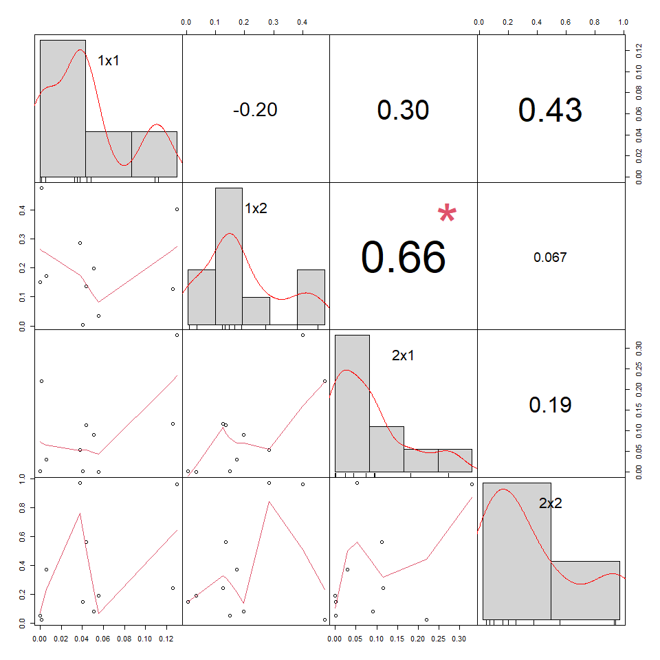

png 2

Computing the p-values (that does not appear in the figure) for the significant correlation:

| 1x1 | 1x2 | 2x1 | 2x2 |
| --- | --- | --- | --- |
| 0.0439 | 0.1364 | 0.1132 | 0.5612 |
| 0.1296 | 0.4012 | 0.3307 | 0.9624 |
| 0.0002 | 0.1508 | 0.0015 | 0.0492 |
| 0.0554 | 0.0341 | 0.0000 | 0.1878 |
| 0.1259 | 0.1266 | 0.1162 | 0.2434 |
| 0.0379 | 0.2850 | 0.0528 | 0.9722 |
| 0.0512 | 0.1980 | 0.0902 | 0.0817 |
| 0.0405 | 0.0051 | 0.0012 | 0.1463 |
| 0.0058 | 0.1726 | 0.0297 | 0.3730 |
| 0.0016 | 0.4750 | 0.2203 | 0.0228 |

```
    Spearman's rank correlation rho

data:  results.cor.test %>% pull(2) and results.cor.test %>% pull(3)
S = 56, p-value = 0.04403
alternative hypothesis: true rho is not equal to 0
sample estimates:
      rho
0.6606061
```

## 5.3 Comparison of within-trial and between-trial conditions in 2x2 and 1x2

Contrasting the occurrence of phonetic contrasts as target contrast and contexts in 2x2 and 1x2 to compare within-trial and between-trial conditions: Selecting the subset of data:

| protocol | hypothesis | contrast | context | effect.size.target | p.value.target | effect.size.context | p.value.context |
| --- | --- | --- | --- | --- | --- | --- | --- |
| 2x2 | 1 | p-b | i_i_, a_a_ | 0.5612 | 0.0000 | 0.1974 | 0.0067 |
| 2x2 | 2 | i-a | _b_b, _p_p | 0.9624 | 0.0000 | 0.0000 | 0.8327 |
| 2x2 | 3 | t-s | a_a_, i_i_ | 0.0492 | 0.2014 | 0.0887 | 0.0799 |
| 2x2 | 4 | i-a | _s_s, _t_t | 0.1878 | 0.0105 | 0.0008 | 0.8812 |
| 2x2 | 5 | n-k | a_a_, #i_i_ | 0.2434 | 0.0044 | 0.1314 | 0.0415 |
| 2x2 | 6 | i-a | _k_k, _n_n | 0.9722 | 0.0000 | 0.3080 | 0.0740 |
| 1x2 | 1 | p-b | i_i_, a_a_ | 0.1364 | 0.0066 | 0.0046 | 0.6396 |
| 1x2 | 2 | i-a | _b_b, _p_p | 0.4012 | 0.0000 | 0.0027 | 0.7367 |
| 1x2 | 3 | t-s | a_a_, i_i_ | 0.1508 | 0.0055 | 0.0053 | 0.6251 |
| 1x2 | 4 | i-a | _s_s, _t_t | 0.0341 | 0.1843 | 0.0003 | 0.9052 |
| 1x2 | 5 | n-k | a_a_, i_i_ | 0.1266 | 0.0086 | 0.0041 | 0.6563 |
| 1x2 | 6 | i-a | _k_k, _n_n | 0.2850 | 0.0001 | 0.0000 | 1.0000 |

We need to gather all the p-values together (both for the target contrasts and the contexts) to apply correction (wide to long transformation for the p-values):

| protocol | hypothesis | contrast | context | effect.size.target | effect.size.context | condition | p.value | p.value.cor |
| --- | --- | --- | --- | --- | --- | --- | --- | --- |
| 2x2 | 1 | p-b | i_i_, a_a_ | 0.5612 | 0.1974 | p.value.target | 0.0000 | 0.0000 |
| 2x2 | 2 | i-a | _b_b, _p_p | 0.9624 | 0.0000 | p.value.target | 0.0000 | 0.0000 |
| 2x2 | 3 | t-s | a_a_, i_i_ | 0.0492 | 0.0887 | p.value.target | 0.2014 | 0.3021 |
| 2x2 | 4 | i-a | _s_s, _t_t | 0.1878 | 0.0008 | p.value.target | 0.0105 | 0.0229 |
| 2x2 | 5 | n-k | a_a_, #i_i_ | 0.2434 | 0.1314 | p.value.target | 0.0044 | 0.0174 |
| 2x2 | 6 | i-a | _k_k, _n_n | 0.9722 | 0.3080 | p.value.target | 0.0000 | 0.0000 |
| 1x2 | 1 | p-b | i_i_, a_a_ | 0.1364 | 0.0046 | p.value.target | 0.0066 | 0.0180 |
| 1x2 | 2 | i-a | _b_b, _p_p | 0.4012 | 0.0027 | p.value.target | 0.0000 | 0.0000 |
| 1x2 | 3 | t-s | a_a_, i_i_ | 0.1508 | 0.0053 | p.value.target | 0.0055 | 0.0180 |
| 1x2 | 4 | i-a | _s_s, _t_t | 0.0341 | 0.0003 | p.value.target | 0.1843 | 0.2948 |
| 1x2 | 5 | n-k | a_a_, i_i_ | 0.1266 | 0.0041 | p.value.target | 0.0086 | 0.0207 |
| 1x2 | 6 | i-a | _k_k, _n_n | 0.2850 | 0.0000 | p.value.target | 0.0001 | 0.0003 |
| 2x2 | 1 | p-b | i_i_, a_a_ | 0.5612 | 0.1974 | p.value.context | 0.0067 | 0.0180 |
| 2x2 | 2 | i-a | _b_b, _p_p | 0.9624 | 0.0000 | p.value.context | 0.8327 | 0.9445 |
| 2x2 | 3 | t-s | a_a_, i_i_ | 0.0492 | 0.0887 | p.value.context | 0.0799 | 0.1370 |
| 2x2 | 4 | i-a | _s_s, _t_t | 0.1878 | 0.0008 | p.value.context | 0.8812 | 0.9445 |
| 2x2 | 5 | n-k | a_a_, #i_i_ | 0.2434 | 0.1314 | p.value.context | 0.0415 | 0.0831 |
| 2x2 | 6 | i-a | _k_k, _n_n | 0.9722 | 0.3080 | p.value.context | 0.0740 | 0.1365 |
| 1x2 | 1 | p-b | i_i_, a_a_ | 0.1364 | 0.0046 | p.value.context | 0.6396 | 0.8290 |
| 1x2 | 2 | i-a | _b_b, _p_p | 0.4012 | 0.0027 | p.value.context | 0.7367 | 0.8840 |
| 1x2 | 3 | t-s | a_a_, i_i_ | 0.1508 | 0.0053 | p.value.context | 0.6251 | 0.8290 |
| 1x2 | 4 | i-a | _s_s, _t_t | 0.0341 | 0.0003 | p.value.context | 0.9052 | 0.9445 |
| 1x2 | 5 | n-k | a_a_, i_i_ | 0.1266 | 0.0041 | p.value.context | 0.6563 | 0.8290 |
| 1x2 | 6 | i-a | _k_k, _n_n | 0.2850 | 0.0000 | p.value.context | 1.0000 | 1.0000 |

Then, we back transform the table from long to wide for the (now corrected) p-values:

| protocol | hypothesis | contrast | context | effect.size.target | effect.size.context | p.value.target | p.value.context |
| --- | --- | --- | --- | --- | --- | --- | --- |
| 1x2 | 1 | p-b | i_i_, a_a_ | 0.1364 | 0.0046 | 0.0180 | 0.8290 |
| 1x2 | 2 | i-a | _b_b, _p_p | 0.4012 | 0.0027 | 0.0000 | 0.8840 |
| 1x2 | 3 | t-s | a_a_, i_i_ | 0.1508 | 0.0053 | 0.0180 | 0.8290 |
| 1x2 | 4 | i-a | _s_s, _t_t | 0.0341 | 0.0003 | 0.2948 | 0.9445 |
| 1x2 | 5 | n-k | a_a_, i_i_ | 0.1266 | 0.0041 | 0.0207 | 0.8290 |
| 1x2 | 6 | i-a | _k_k, _n_n | 0.2850 | 0.0000 | 0.0003 | 1.0000 |
| 2x2 | 1 | p-b | i_i_, a_a_ | 0.5612 | 0.1974 | 0.0000 | 0.0180 |
| 2x2 | 2 | i-a | _b_b, _p_p | 0.9624 | 0.0000 | 0.0000 | 0.9445 |
| 2x2 | 3 | t-s | a_a_, i_i_ | 0.0492 | 0.0887 | 0.3021 | 0.1370 |
| 2x2 | 4 | i-a | _s_s, _t_t | 0.1878 | 0.0008 | 0.0229 | 0.9445 |
| 2x2 | 5 | n-k | a_a_, #i_i_ | 0.2434 | 0.1314 | 0.0174 | 0.0831 |
| 2x2 | 6 | i-a | _k_k, _n_n | 0.9722 | 0.3080 | 0.0000 | 0.1365 |

Effect sizes for the target phonetic contrast:

```r
results.hyp.1to6.cor %>% select(hypothesis, effect.size.target, protocol) %>%
    spread(protocol, effect.size.target) %>% kable(digits=4)
```

| hypothesis | 1x2 | 2x2 |
| --- | --- | --- |
| 1 | 0.1364 | 0.5612 |
| 2 | 0.4012 | 0.9624 |
| 3 | 0.1508 | 0.0492 |
| 4 | 0.0341 | 0.1878 |
| 5 | 0.1266 | 0.2434 |
| 6 | 0.2850 | 0.9722 |

Effect sizes for the context:

```r
results.hyp.1to6.cor %>% select(hypothesis, effect.size.context, protocol) %>%
    spread(protocol, effect.size.context) %>% kable(digits=4)
```

| hypothesis | 1x2 | 2x2 |
| --- | --- | --- |
| 1 | 0.0046 | 0.1974 |
| 2 | 0.0027 | 0.0000 |
| 3 | 0.0053 | 0.0887 |
| 4 | 0.0003 | 0.0008 |
| 5 | 0.0041 | 0.1314 |
| 6 | 0.0000 | 0.3080 |

p-values for the effect of the target phonetic contrast:

```r
results.hyp.1to6.cor %>% select(hypothesis, p.value.target, protocol) %>%
    spread(protocol, p.value.target) %>% kable(digits=4)
```

| hypothesis | 1x2 | 2x2 |
| --- | --- | --- |
| 1 | 0.0180 | 0.0000 |
| 2 | 0.0000 | 0.0000 |
| 3 | 0.0180 | 0.3021 |
| 4 | 0.2948 | 0.0229 |
| 5 | 0.0207 | 0.0174 |
| 6 | 0.0003 | 0.0000 |

p-values for the effect of the context:

```r
results.hyp.1to6.cor %>% select(hypothesis, p.value.context, protocol) %>%
    spread(protocol, p.value.context) %>% kable(digits=4)
```

| hypothesis | 1x2 | 2x2 |
| --- | --- | --- |
| 1 | 0.8290 | 0.0180 |
| 2 | 0.8840 | 0.9445 |
| 3 | 0.8290 | 0.1370 |
| 4 | 0.9445 | 0.9445 |
| 5 | 0.8290 | 0.0831 |
| 6 | 1.0000 | 0.1365 |

## 5.4 Figures for the interactions between target contrast and context

Creating and saving figures for the detected interactions between target contrast and context:

2x1, Hypotheses 5 and 6

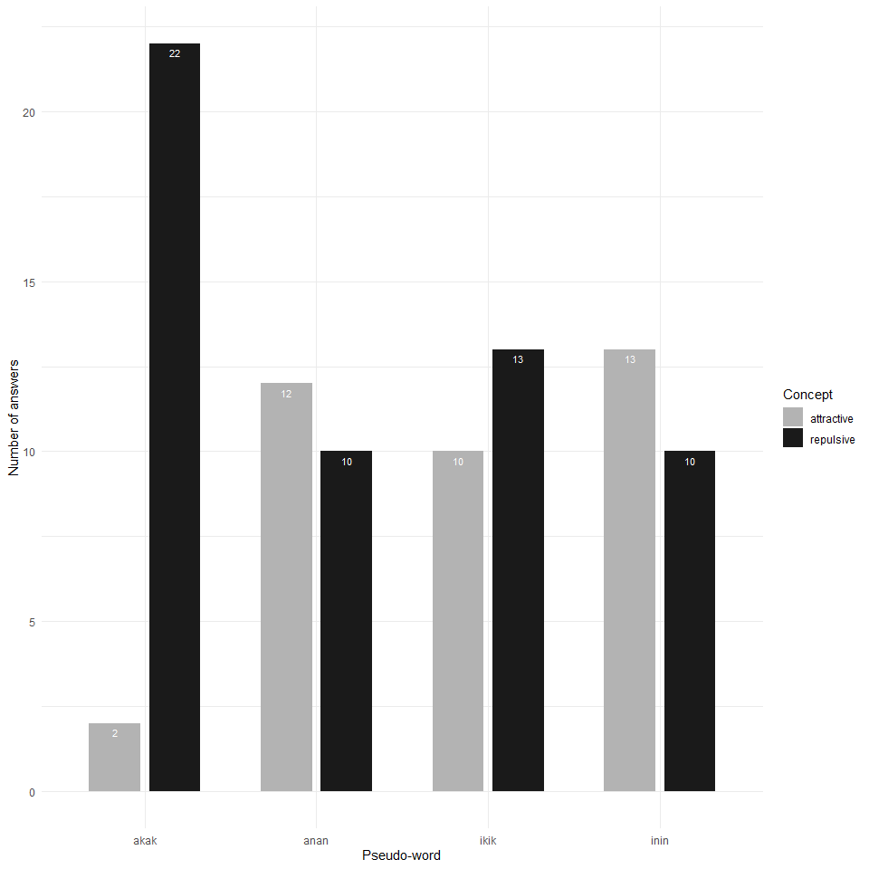

1x2, Hypothesis 6

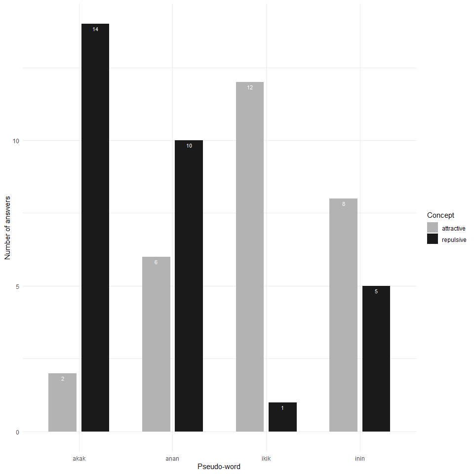

2x1, Hypothesis 8

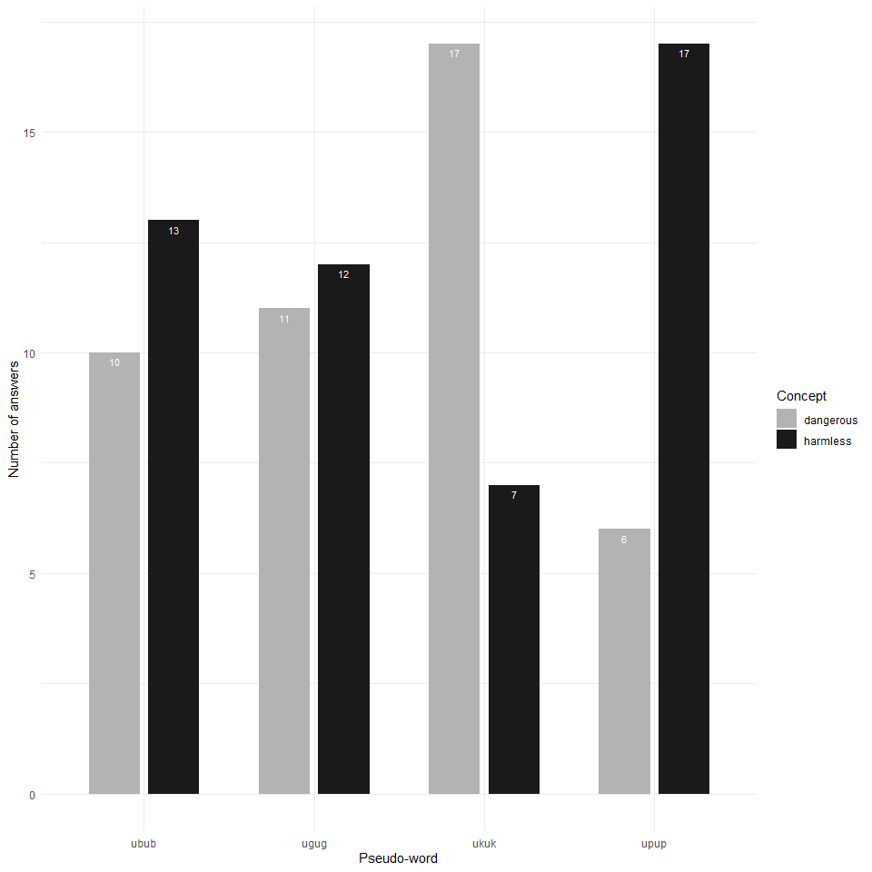

1x1, Hypothesis 7

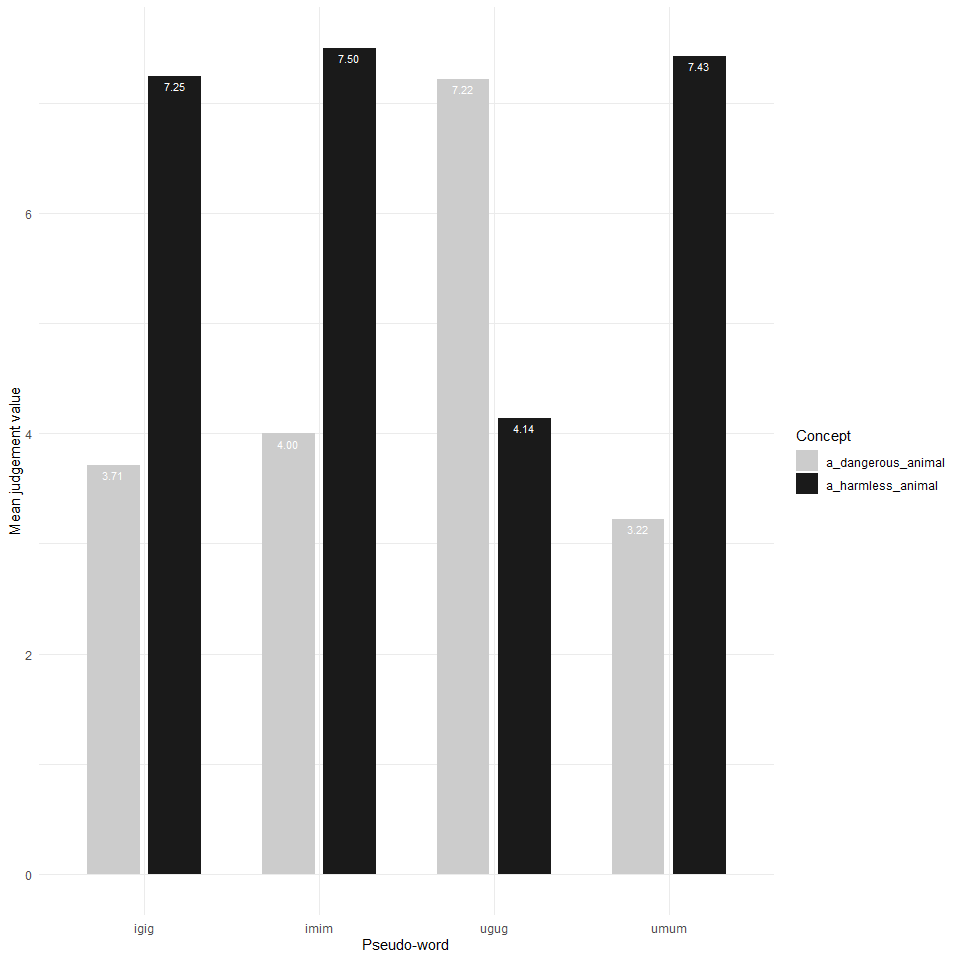

## 5.5 Distribution of answers in 1x1

We display the distribution of answers in 1x1 to assess participants’ tendencies to choose average or more extreme values:

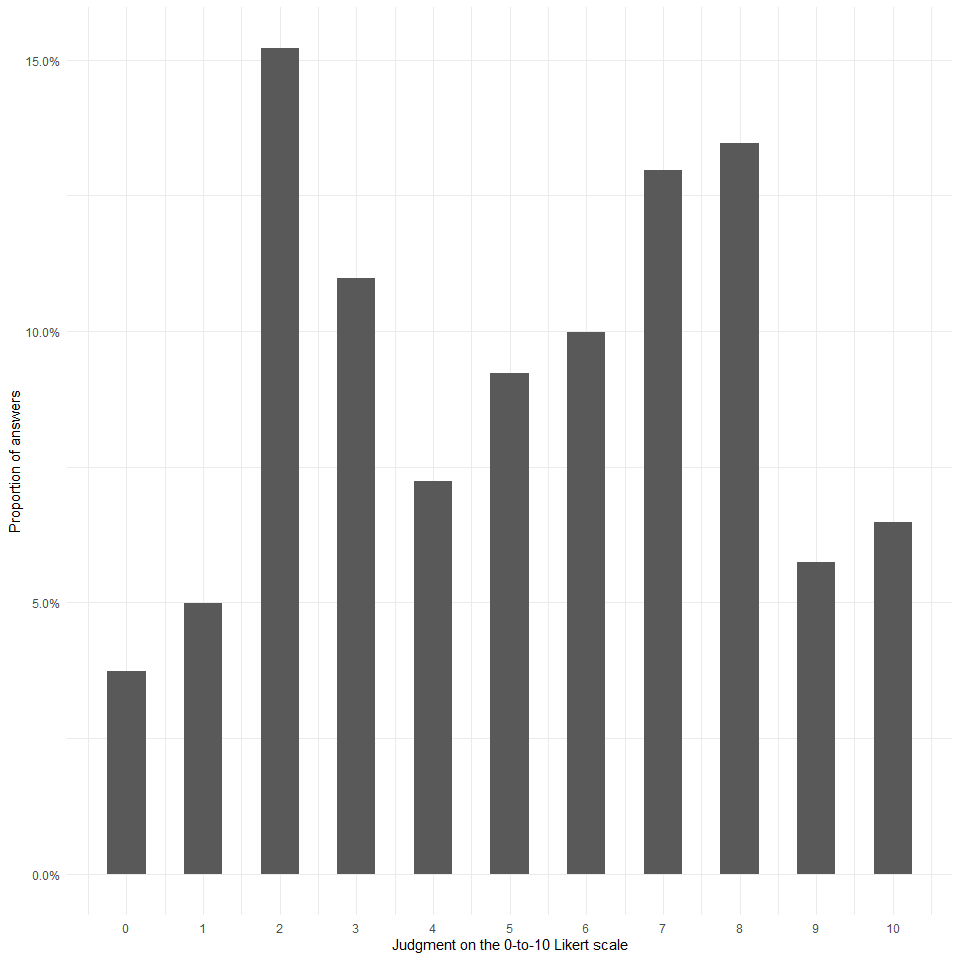

```r
p <- expe11 %>%
  ggplot(aes(x=judgment)) +
  geom_histogram(aes(y = stat(count / sum(count))), binwidth = 0.5) +
  ylab("Proportion of answers") + xlab("Judgment on the 0-to-10 Likert scale") +
  scale_y_continuous(labels = percent_format()) +
  scale_x_continuous(breaks=seq(0,10,1)) +
  scale_fill_manual(values = c("grey80","grey10")) +
  theme_minimal()

p
```

```r
ggsave("Distribution_judgments_1x1.tiff", plot = p, device = 'tiff', path = my_path,
       scale = 1, width = 8, height = 6, units = "in", dpi = 150)
```

## 5.6 Comparisons of different measures of effect size

Creating, displaying and saving plots of comparisons of different measures of effect size (Cramer’s V and partial McKelvey & Zavoina pseudo-R² for 2x2, 2x1 and 1x2, eta² and partial McKelvey & Zavoina pseudo-R² for 1x1):

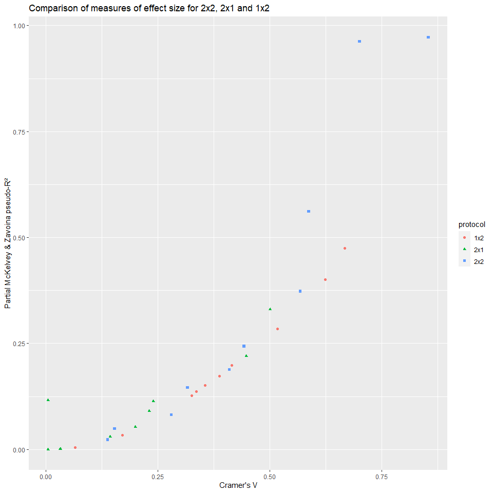

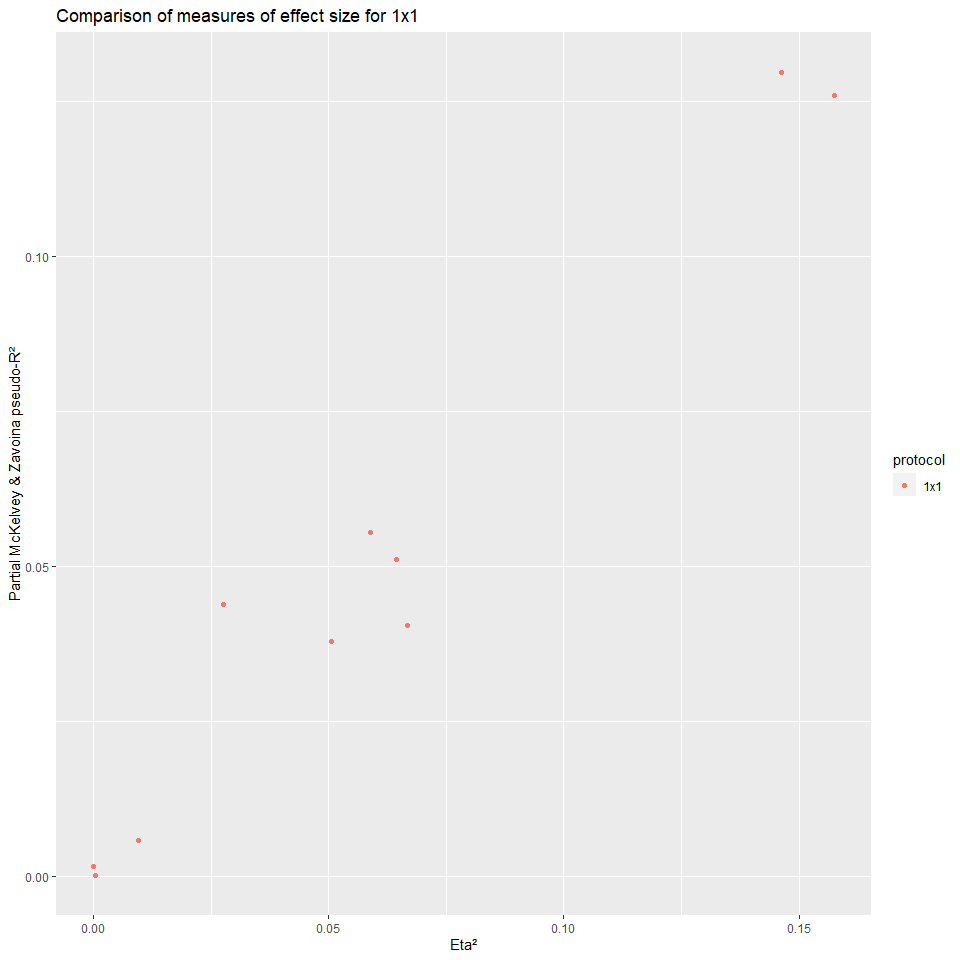